# Pipeline Project

You will be using the provided data to create a machine learning model pipeline.

You must handle the data appropriately in your pipeline to predict whether an item is recommended by a customer based on their review. Note the data includes numerical, categorical, and text data.

You should ensure you properly train and evaluate your model.

## The Data

The dataset has been anonymized and cleaned of missing values.

There are 8 features for to use to predict whether a customer recommends or does not recommend a product. The `Recommended IND` column gives whether a customer recommends the product where `1` is recommended and a `0` is not recommended. This is your model's target/

The features can be summarized as the following:

- **Clothing ID**: Integer Categorical variable that refers to the specific piece being reviewed.
- **Age**: Positive Integer variable of the reviewers age.
- **Title**: String variable for the title of the review.
- **Review Text**: String variable for the review body.
- **Positive Feedback Count**: Positive Integer documenting the number of other customers who found this review positive.
- **Division Name**: Categorical name of the product high level division.
- **Department Name**: Categorical name of the product department name.
- **Class Name**: Categorical name of the product class name.

The target:

- **Recommended IND**: Binary variable stating where the customer recommends the product where 1 is recommended, 0 is not recommended.

## Load Data

```python
import pandas as pd

# Load data
df = pd.read_csv(
    'data/reviews.csv',
)

df.info()
df.head()
```

```
<class 'pandas.DataFrame'>
RangeIndex: 18442 entries, 0 to 18441
Data columns (total 9 columns):
 #   Column                   Non-Null Count  Dtype
---  ------                   --------------  -----
 0   Clothing ID              18442 non-null  int64
 1   Age                      18442 non-null  int64
 2   Title                    18442 non-null  str
 3   Review Text              18442 non-null  str
 4   Positive Feedback Count  18442 non-null  int64
 5   Division Name            18442 non-null  str
 6   Department Name          18442 non-null  str
 7   Class Name               18442 non-null  str
 8   Recommended IND          18442 non-null  int64
dtypes: int64(4), str(5)
memory usage: 1.3 MB
```

|  | Clothing ID | Age | Title | Review Text | Positive Feedback Count | Division Name | Department Name | Class Name | Recommended IND |
| --- | --- | --- | --- | --- | --- | --- | --- | --- | --- |
| 0 | 1077 | 60 | Some major design flaws | I had such high hopes for this dress and reall... | 0 | General | Dresses | Dresses | 0 |
| 1 | 1049 | 50 | My favorite buy! | I love, love, love this jumpsuit. it's fun, fl... | 0 | General Petite | Bottoms | Pants | 1 |
| 2 | 847 | 47 | Flattering shirt | This shirt is very flattering to all due to th... | 6 | General | Tops | Blouses | 1 |
| 3 | 1080 | 49 | Not for the very petite | I love tracy reese dresses, but this one is no... | 4 | General | Dresses | Dresses | 0 |
| 4 | 858 | 39 | Cagrcoal shimmer fun | I aded this in my basket at hte last mintue to... | 1 | General Petite | Tops | Knits | 1 |

## Preparing features (`X`) & target (`y`)

```python
data = df

# separate features from labels
X = data.drop('Recommended IND', axis=1)
y = data['Recommended IND'].copy()

print('Labels:', y.unique())
print('Features:')
display(X.head())
```

```
Labels: [0 1]
Features:
```

|  | Clothing ID | Age | Title | Review Text | Positive Feedback Count | Division Name | Department Name | Class Name |
| --- | --- | --- | --- | --- | --- | --- | --- | --- |
| 0 | 1077 | 60 | Some major design flaws | I had such high hopes for this dress and reall... | 0 | General | Dresses | Dresses |
| 1 | 1049 | 50 | My favorite buy! | I love, love, love this jumpsuit. it's fun, fl... | 0 | General Petite | Bottoms | Pants |
| 2 | 847 | 47 | Flattering shirt | This shirt is very flattering to all due to th... | 6 | General | Tops | Blouses |
| 3 | 1080 | 49 | Not for the very petite | I love tracy reese dresses, but this one is no... | 4 | General | Dresses | Dresses |
| 4 | 858 | 39 | Cagrcoal shimmer fun | I aded this in my basket at hte last mintue to... | 1 | General Petite | Tops | Knits |

```python
# Split data into train and test sets
from sklearn.model_selection import train_test_split

X_train, X_test, y_train, y_test = train_test_split(
    X,
    y,
    test_size=0.1,
    shuffle=True,
    random_state=27,
)
```

# Your Work

## Data Exploration

### Imports & Setup

```python
import matplotlib.pyplot as plt
import seaborn as sns
import numpy as np

sns.set_style("whitegrid")
plt.rcParams['figure.figsize'] = (12, 5)
```

### Base statistics (numerical)

```python
print("=== Shape ===")
print(f"Rows: {df.shape[0]:,} | Columns: {df.shape[1]}")

print("\n=== Numerical Columns ===")
display(df.describe())

print("\n=== Categorical Columns ===")
df.describe(include=['object', 'str'])
```

```
=== Shape ===
Rows: 18,442 | Columns: 9

=== Numerical Columns ===
```

|  | Clothing ID | Age | Positive Feedback Count | Recommended IND |
| --- | --- | --- | --- | --- |
| count | 18442.000000 | 18442.000000 | 18442.000000 | 18442.000000 |
| mean | 954.896757 | 43.383635 | 2.697484 | 0.816235 |
| std | 141.571783 | 12.246264 | 5.942220 | 0.387303 |
| min | 2.000000 | 18.000000 | 0.000000 | 0.000000 |
| 25% | 863.000000 | 34.000000 | 0.000000 | 1.000000 |
| 50% | 952.000000 | 41.000000 | 1.000000 | 1.000000 |
| 75% | 1078.000000 | 52.000000 | 3.000000 | 1.000000 |
| max | 1205.000000 | 99.000000 | 122.000000 | 1.000000 |

```
=== Categorical Columns ===
```

|  | Title | Review Text | Division Name | Department Name | Class Name |
| --- | --- | --- | --- | --- | --- |
| count | 18442 | 18442 | 18442 | 18442 | 18442 |
| unique | 13142 | 18439 | 2 | 6 | 14 |
| top | Love it! | I purchased this and another eva franco dress ... | General | Tops | Dresses |
| freq | 129 | 2 | 11664 | 8713 | 5371 |

### Correlation matrix (numerical Features)

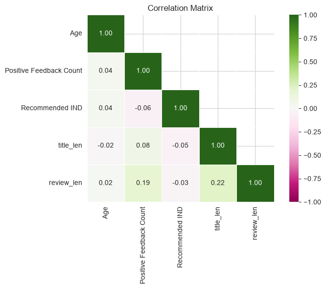

```python
# Temporarily create text length columns
df['title_len'] = df['Title'].astype(str).apply(len)
df['review_len'] = df['Review Text'].astype(str).apply(len)

numeric_cols = ['Age', 'Positive Feedback Count', 'Recommended IND',
                'title_len', 'review_len']

corr = df[numeric_cols].corr()

mask = np.triu(np.ones_like(corr, dtype=bool), k=1)

plt.figure(figsize=(8, 6))
sns.heatmap(
    corr, annot=True, fmt='.2f', cmap='PiYG', center=0,
    square=True, linewidths=0.5, mask=mask,
    vmin=-1, vmax=1
)
plt.title('Correlation Matrix')
plt.tight_layout()
plt.show()

# Cleanup
df.drop(columns=['title_len', 'review_len'], inplace=True)
```

### Recommendation distribution

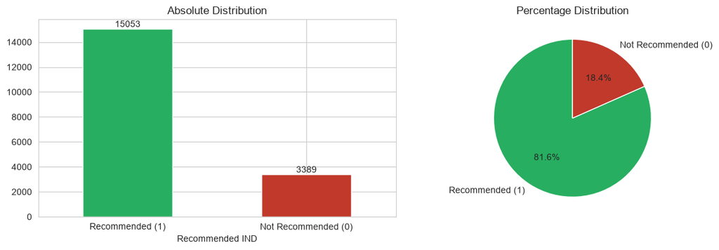

```
Class Balance Ratio: 81.62% recommended
```

```python
fig, axes = plt.subplots(1, 2, figsize=(12, 4))

# Farb- und Label-Map
color_map = {0: '#c0392b', 1: '#27ae60'}
label_map = {0: 'Not Recommended (0)', 1: 'Recommended (1)'}

# Absolute Werte
counts = df['Recommended IND'].value_counts().sort_index(ascending=False)
colors = [color_map[idx] for idx in counts.index]

counts.plot(kind='bar', ax=axes[0], color=colors)
axes[0].set_title('Absolute Distribution')
axes[0].set_xticklabels([label_map[idx] for idx in counts.index], rotation=0)
axes[0].bar_label(axes[0].containers[0])

# Prozentual (direkt über matplotlib)
counts_norm = df['Recommended IND'].value_counts(normalize=True).sort_index(ascending=False)
colors_pie = [color_map[idx] for idx in counts_norm.index]
labels_pie = [label_map[idx] for idx in counts_norm.index]

axes[1].pie(
    counts_norm.values,
    labels=labels_pie,
    colors=colors_pie,
    autopct='%1.1f%%',
    startangle=90
)
axes[1].set_title('Percentage Distribution')

plt.tight_layout()
plt.show()

print(f"Class Balance Ratio: {df['Recommended IND'].mean():.2%} recommended")
```

### Categorial Features (Division, Department, Class)

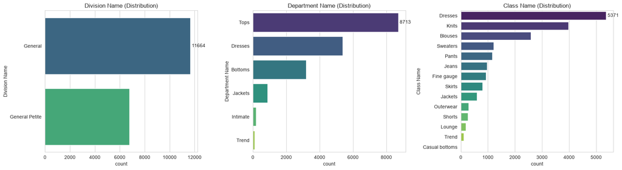

```python
fig, axes = plt.subplots(1, 3, figsize=(18, 5))

for i, col in enumerate(['Division Name', 'Department Name', 'Class Name']):
    order = df[col].value_counts().index
    sns.countplot(
        data=df, y=col, order=order, ax=axes[i],
        hue=col, hue_order=order, palette='viridis', legend=False
    )
    axes[i].set_title(f'{col} (Distribution)')
    axes[i].bar_label(axes[i].containers[0], padding=3)

plt.tight_layout()
plt.show()
```

### Recommendation per category

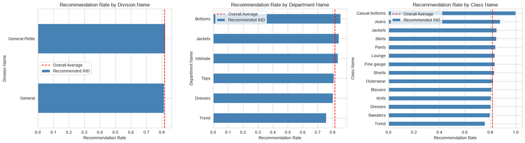

```python
fig, axes = plt.subplots(1, 3, figsize=(18, 5))

for i, col in enumerate(['Division Name', 'Department Name', 'Class Name']):
    rec_rate = df.groupby(col)['Recommended IND'].mean().sort_values(ascending=True)
    rec_rate.plot(kind='barh', ax=axes[i], color='steelblue')
    axes[i].set_title(f'Recommendation Rate by {col}')
    axes[i].set_xlabel('Recommendation Rate')
    axes[i].axvline(df['Recommended IND'].mean(), color='red', linestyle='--', label='Overall Average')
    axes[i].legend()

plt.tight_layout()
plt.show()
```

### Age distribution

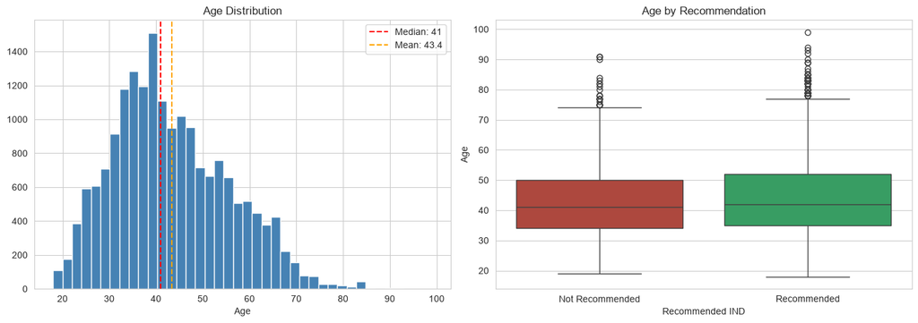

```python
fig, axes = plt.subplots(1, 2, figsize=(14, 5))

# Histogramm
df['Age'].hist(bins=40, ax=axes[0], color='steelblue', edgecolor='white')
axes[0].axvline(df['Age'].median(), color='red', linestyle='--', label=f"Median: {df['Age'].median():.0f}")
axes[0].axvline(df['Age'].mean(), color='orange', linestyle='--', label=f"Mean: {df['Age'].mean():.1f}")
axes[0].set_title('Age Distribution')
axes[0].set_xlabel('Age')
axes[0].legend()

# Boxplot by Target (hue statt palette, feste Ticks)
sns.boxplot(
    data=df, x='Recommended IND', y='Age', ax=axes[1],
    hue='Recommended IND', palette={0: '#c0392b', 1: '#27ae60'}, legend=False
)
axes[1].set_title('Age by Recommendation')
axes[1].set_xticks([0, 1])
axes[1].set_xticklabels(['Not Recommended', 'Recommended'])

plt.tight_layout()
plt.show()
```

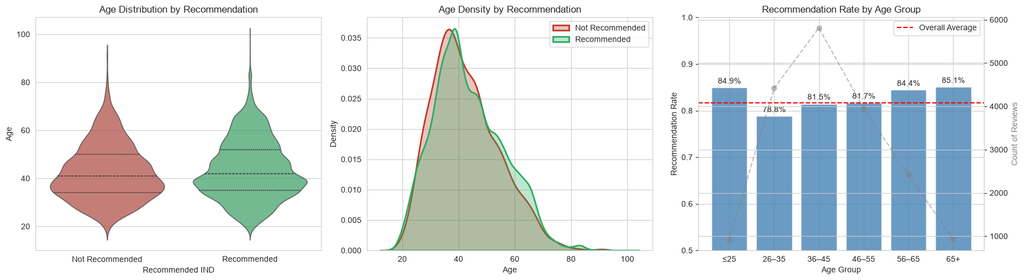

```python
fig, axes = plt.subplots(1, 3, figsize=(18, 5))

# 1) Violin + Strip Plot
sns.violinplot(
    data=df, x='Recommended IND', y='Age', ax=axes[0],
    hue='Recommended IND', palette={0: '#c0392b', 1: '#27ae60'},
    legend=False, inner='quartile', alpha=0.7
)
axes[0].set_title('Age Distribution by Recommendation')
axes[0].set_xticks([0, 1])
axes[0].set_xticklabels(['Not Recommended', 'Recommended'])

# 2) KDE Overlay
for label, color, name in [(0, '#c0392b', 'Not Recommended'), (1, '#27ae60', 'Recommended')]:
    sns.kdeplot(
        df[df['Recommended IND'] == label]['Age'],
        ax=axes[1], color=color, fill=True, alpha=0.3, label=name, linewidth=2
    )
axes[1].set_title('Age Density by Recommendation')
axes[1].set_xlabel('Age')
axes[1].legend()

# 3) Recommendation Rate by Age Group
df['age_group'] = pd.cut(df['Age'], bins=[0, 25, 35, 45, 55, 65, 100],
                          labels=['≤25', '26–35', '36–45', '46–55', '56–65', '65+'])

age_stats = df.groupby('age_group', observed=True).agg(
    rec_rate=('Recommended IND', 'mean'),
    count=('Recommended IND', 'size')
).reset_index()

bar = axes[2].bar(age_stats['age_group'], age_stats['rec_rate'], color='steelblue', alpha=0.8)
axes[2].bar_label(bar, fmt='%.1f%%', label_type='edge', padding=3,
                   labels=[f"{v:.1%}" for v in age_stats['rec_rate']])
axes[2].axhline(df['Recommended IND'].mean(), color='red', linestyle='--', label='Overall Average')
axes[2].set_title('Recommendation Rate by Age Group')
axes[2].set_xlabel('Age Group')
axes[2].set_ylabel('Recommendation Rate')
axes[2].set_ylim(0.5, 1.0)
axes[2].legend()

# Count Reviews as secondary info
ax2 = axes[2].twinx()
ax2.plot(age_stats['age_group'], age_stats['count'], color='gray', marker='o', linestyle='--', alpha=0.5)
ax2.set_ylabel('Count of Reviews', color='gray')

plt.tight_layout()
plt.show()

# Cleanup
df.drop(columns=['age_group'], inplace=True, errors='ignore')
```

### Positive Feedback Count

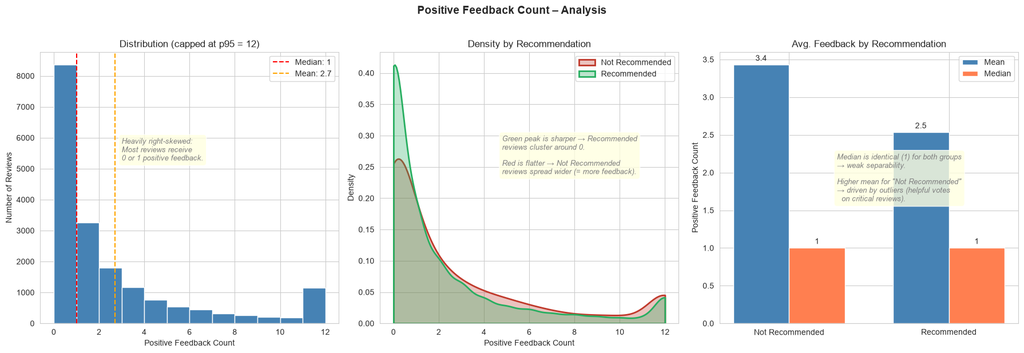

```python
fig, axes = plt.subplots(1, 3, figsize=(18, 6))
fig.suptitle('Positive Feedback Count – Analysis', fontsize=14, fontweight='bold', y=1.02)

# --- 1) Histogram (capped at p95) ---
cap = int(df['Positive Feedback Count'].quantile(0.95))
data_capped = df['Positive Feedback Count'].clip(upper=cap)

data_capped.hist(bins=cap, ax=axes[0], color='steelblue', edgecolor='white')
axes[0].axvline(df['Positive Feedback Count'].median(), color='red', linestyle='--',
                label=f"Median: {df['Positive Feedback Count'].median():.0f}")
axes[0].axvline(df['Positive Feedback Count'].mean(), color='orange', linestyle='--',
                label=f"Mean: {df['Positive Feedback Count'].mean():.1f}")
axes[0].set_title(f'Distribution (capped at p95 = {cap})')
axes[0].set_xlabel('Positive Feedback Count')
axes[0].set_ylabel('Number of Reviews')
axes[0].legend()

# Annotation
axes[0].annotate(
    'Heavily right-skewed:\nMost reviews receive\n0 or 1 positive feedback.',
    xy=(3, axes[0].get_ylim()[1] * 0.6),
    fontsize=9, fontstyle='italic', color='gray',
    bbox=dict(boxstyle='round,pad=0.4', fc='lightyellow', alpha=0.8)
)

# --- 2) KDE  ---
for label, color, name in [(0, '#c0392b', 'Not Recommended'), (1, '#27ae60', 'Recommended')]:
    sns.kdeplot(
        df[df['Recommended IND'] == label]['Positive Feedback Count'].clip(upper=cap),
        ax=axes[1], color=color, fill=True, alpha=0.3, label=name, linewidth=2,
        clip=(0, cap)  # prevents negative x-axis artifact
    )
axes[1].set_title('Density by Recommendation')
axes[1].set_xlabel('Positive Feedback Count')
axes[1].set_ylabel('Density')
axes[1].legend()

# Annotation
axes[1].annotate(
    'Green peak is sharper → Recommended\n'
    'reviews cluster around 0.\n\n'
    'Red is flatter → Not Recommended\n'
    'reviews spread wider (= more feedback).',
    xy=(cap * 0.4, axes[1].get_ylim()[1] * 0.55),
    fontsize=9, fontstyle='italic', color='gray',
    bbox=dict(boxstyle='round,pad=0.4', fc='lightyellow', alpha=0.8)
)

# --- 3) Grouped Bar (Mean vs Median) ---
stats = df.groupby('Recommended IND')['Positive Feedback Count'].agg(['mean', 'median'])

x = np.arange(2)
width = 0.35
bar_mean = axes[2].bar(x - width/2, stats['mean'], width, color='steelblue', label='Mean')
bar_med = axes[2].bar(x + width/2, stats['median'], width, color='coral', label='Median')
axes[2].bar_label(bar_mean, fmt='%.1f', padding=3)
axes[2].bar_label(bar_med, fmt='%.0f', padding=3)
axes[2].set_title('Avg. Feedback by Recommendation')
axes[2].set_xticks(x)
axes[2].set_xticklabels(['Not Recommended', 'Recommended'])
axes[2].set_ylabel('Positive Feedback Count')
axes[2].legend()

# Annotation
axes[2].annotate(
    'Median is identical (1) for both groups\n'
    '→ weak separability.\n\n'
    'Higher mean for "Not Recommended"\n'
    '→ driven by outliers (helpful votes\n'
    '  on critical reviews).',
    xy=(0.3, axes[2].get_ylim()[1] * 0.45),
    fontsize=9, fontstyle='italic', color='gray',
    bbox=dict(boxstyle='round,pad=0.4', fc='lightyellow', alpha=0.8)
)

plt.tight_layout()
plt.show()
```

```python
# Summary print
print("=" * 60)
print("KEY FINDINGS: Positive Feedback Count")
print("=" * 60)
print(f"  Median:          {df['Positive Feedback Count'].median():.0f}")
print(f"  Mean:            {df['Positive Feedback Count'].mean():.1f}")
print(f"  Max:             {df['Positive Feedback Count'].max()}")
print(f"  95th Percentile: {df['Positive Feedback Count'].quantile(0.95):.0f}")
print(f"  Zero-Feedback:   {(df['Positive Feedback Count'] == 0).mean():.1%} of all reviews")
print("-" * 60)
print("  → Consider log1p transform or binary feature (has_feedback)")
print("  → Weak predictor on its own due to identical medians")
print("=" * 60)
```

```
============================================================
KEY FINDINGS: Positive Feedback Count
============================================================
  Median:          1
  Mean:            2.7
  Max:             122
  95th Percentile: 12
  Zero-Feedback:   45.3% of all reviews
------------------------------------------------------------
  → Consider log1p transform or binary feature (has_feedback)
  → Weak predictor on its own due to identical medians
============================================================
```

### Text length analysis (Title & Review Text)

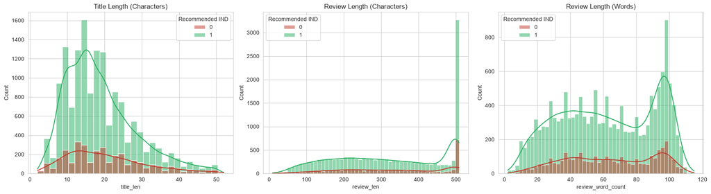

```python
df['title_len'] = df['Title'].astype(str).apply(len)
df['review_len'] = df['Review Text'].astype(str).apply(len)
df['review_word_count'] = df['Review Text'].astype(str).apply(lambda x: len(x.split()))

fig, axes = plt.subplots(1, 3, figsize=(18, 5))

# Title Length
sns.histplot(data=df, x='title_len', hue='Recommended IND', ax=axes[0],
             palette=['#c0392b', '#27ae60'], bins=30, kde=True)
axes[0].set_title('Title Length (Characters)')

# Review Length
sns.histplot(data=df, x='review_len', hue='Recommended IND', ax=axes[1],
             palette=['#c0392b', '#27ae60'], bins=50, kde=True)
axes[1].set_title('Review Length (Characters)')

# Word Count
sns.histplot(data=df, x='review_word_count', hue='Recommended IND', ax=axes[2],
             palette=['#c0392b', '#27ae60'], bins=50, kde=True)
axes[2].set_title('Review Length (Words)')

plt.tight_layout()
plt.show()
```

```python
print(df[['title_len', 'review_len', 'review_word_count']].describe().round(1))
```

```
       title_len  review_len  review_word_count
count    18442.0     18442.0            18442.0
mean        19.1       320.0               62.4
std          9.6       142.0               28.1
min          2.0         9.0                2.0
25%         12.0       201.0               39.0
50%         17.0       317.5               62.0
75%         24.0       478.0               90.0
max         52.0       508.0              115.0
```

### Age group vs. recommendation

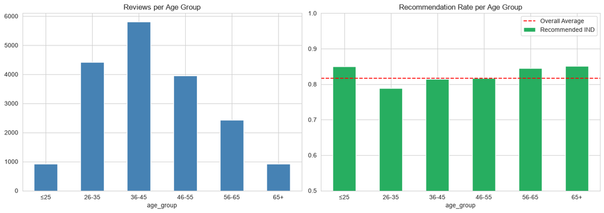

```python
df['age_group'] = pd.cut(df['Age'], bins=[0, 25, 35, 45, 55, 65, 100],
                          labels=['≤25', '26-35', '36-45', '46-55', '56-65', '65+'])

fig, axes = plt.subplots(1, 2, figsize=(14, 5))

# Number of reviews per age group
df['age_group'].value_counts().sort_index().plot(kind='bar', ax=axes[0], color='steelblue')
axes[0].set_title('Reviews per Age Group')
axes[0].set_xticklabels(axes[0].get_xticklabels(), rotation=0)

# Recommendation rate per age group
df.groupby('age_group')['Recommended IND'].mean().plot(kind='bar', ax=axes[1], color='#27ae60')
axes[1].set_title('Recommendation Rate per Age Group')
axes[1].set_xticklabels(axes[1].get_xticklabels(), rotation=0)
axes[1].axhline(df['Recommended IND'].mean(), color='red', linestyle='--', label='Overall Average')
axes[1].set_ylim(0.5, 1.0)
axes[1].legend()

plt.tight_layout()
plt.show()
```

### Top Clothing IDs (most recommended products)

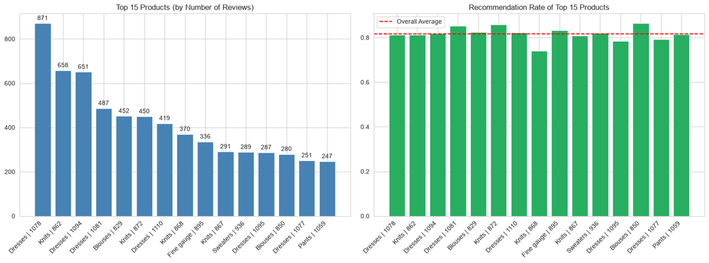

```python
# Create a readable label from available columns
id_labels = (
    df.groupby('Clothing ID')[['Division Name', 'Department Name', 'Class Name']]
    .first()
)

id_labels['label'] = (
    id_labels['Class Name'] + ' | '
    + id_labels.index.astype(str)
)


# Top 15 products
top_products = df['Clothing ID'].value_counts().head(15)
top_ids = top_products.index
labels = [id_labels.loc[cid, 'label'] for cid in top_ids]

fig, axes = plt.subplots(1, 2, figsize=(16, 6))

# Review count
axes[0].bar(range(len(top_ids)), top_products.values, color='steelblue')
axes[0].set_title('Top 15 Products (by Number of Reviews)')
axes[0].set_xticks(range(len(top_ids)))
axes[0].set_xticklabels(labels, rotation=45, ha='right')
axes[0].bar_label(axes[0].containers[0], padding=3)

# Recommendation rate
rec_rates = df[df['Clothing ID'].isin(top_ids)].groupby('Clothing ID')['Recommended IND'].mean()
axes[1].bar(range(len(top_ids)), [rec_rates[cid] for cid in top_ids], color='#27ae60')
axes[1].axhline(df['Recommended IND'].mean(), color='red', linestyle='--', label='Overall Average')
axes[1].set_title('Recommendation Rate of Top 15 Products')
axes[1].set_xticks(range(len(top_ids)))
axes[1].set_xticklabels(labels, rotation=45, ha='right')
axes[1].legend()

plt.tight_layout()
plt.show()
```

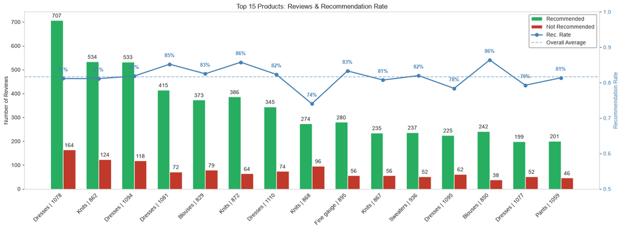

```python
# Create labels
id_labels = (
    df.groupby('Clothing ID')[['Division Name', 'Department Name', 'Class Name']]
    .first()
)
id_labels['label'] = id_labels['Class Name'] + ' | ' + id_labels.index.astype(str)

# Top 15 products
top_ids = df['Clothing ID'].value_counts().head(15).index
labels = [id_labels.loc[cid, 'label'] for cid in top_ids]

# Count recommended vs not recommended per product
counts = (
    df[df['Clothing ID'].isin(top_ids)]
    .groupby(['Clothing ID', 'Recommended IND'])
    .size()
    .unstack(fill_value=0)
)
counts = counts.loc[top_ids]

# Recommendation rate per product
rec_rate = counts[1] / (counts[0] + counts[1])

fig, ax1 = plt.subplots(figsize=(16, 6))

x = np.arange(len(top_ids))
width = 0.35

# Bars
bar_rec = ax1.bar(x - width/2, counts[1], width, color='#27ae60', label='Recommended')
bar_not = ax1.bar(x + width/2, counts[0], width, color='#c0392b', label='Not Recommended')
ax1.bar_label(bar_rec, padding=3)
ax1.bar_label(bar_not, padding=3)
ax1.set_ylabel('Number of Reviews')
ax1.set_xticks(x)
ax1.set_xticklabels(labels, rotation=45, ha='right')
ax1.grid(False)

# Recommendation rate on secondary y-axis
ax2 = ax1.twinx()
ax2.plot(x, rec_rate.values, color='steelblue', marker='o', linewidth=2, label='Rec. Rate', zorder=5)
ax2.axhline(df['Recommended IND'].mean(), color='steelblue', linestyle='--', alpha=0.5, label='Overall Average')
ax2.set_ylabel('Recommendation Rate', color='steelblue')
ax2.set_ylim(0.5, 1.0)
ax2.tick_params(axis='y', labelcolor='steelblue')
ax2.grid(False)

# Percentage labels on the line
for i, val in enumerate(rec_rate.values):
    ax2.text(i, val + 0.02, f'{val:.0%}', ha='center', fontsize=9,
             color='steelblue', fontweight='bold')

# Combined legend
lines1, labels1 = ax1.get_legend_handles_labels()
lines2, labels2 = ax2.get_legend_handles_labels()
ax1.legend(lines1 + lines2, labels1 + labels2, loc='upper right',
           framealpha=0.9, edgecolor='gray')

ax1.set_title('Top 15 Products: Reviews & Recommendation Rate')

plt.tight_layout()
plt.show()
```

### Key Findings

```python
print("=" * 60)
print("EDA SUMMARY")
print("=" * 60)
print(f"  Dataset:              {df.shape[0]:,} Reviews, {df.shape[1]} Columns")
print(f"  Missing Values:       {df.isnull().sum().sum()}")
print(f"  Unique Products:      {df['Clothing ID'].nunique()}")
print(f"  Target Balance:       {df['Recommended IND'].mean():.1%} recommended")
print(f"  Age Range:            {df['Age'].min()} - {df['Age'].max()} (Median: {df['Age'].median():.0f})")
print(f"  Ø Review Length:      {df['Review Text'].astype(str).apply(lambda x: len(x.split())).mean():.0f} Words")
print(f"  Ø Positive Feedback:  {df['Positive Feedback Count'].mean():.1f}")
print("=" * 60)
```

```
============================================================
EDA SUMMARY
============================================================
  Dataset:              18,442 Reviews, 13 Columns
  Missing Values:       0
  Unique Products:      531
  Target Balance:       81.6% recommended
  Age Range:            18 - 99 (Median: 41)
  Ø Review Length:      62 Words
  Ø Positive Feedback:  2.7
============================================================
```

### WordCloud (Review Text)

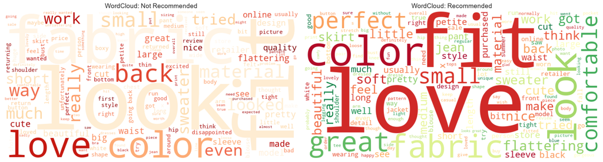

```python
from wordcloud import WordCloud, STOPWORDS

stopwords = set(STOPWORDS)
stopwords.update(['dress', 'top', 'shirt', 'size', 'wear', 'will', 'one', 'ordered', 'bought'])

fig, axes = plt.subplots(1, 2, figsize=(18, 7))

for i, (label, val) in enumerate([(0, 'Not Recommended'), (1, 'Recommended')]):
    text = ' '.join(df[df['Recommended IND'] == label]['Review Text'].astype(str))
    wc = WordCloud(
        width=800, height=400,
        background_color='white',
        stopwords=stopwords,
        max_words=150,
        colormap='RdYlGn' if label == 1 else 'OrRd',
        random_state=42
    ).generate(text)
    axes[i].imshow(wc, interpolation='bilinear')
    axes[i].set_title(f'WordCloud: {val}', fontsize=14)
    axes[i].axis('off')

plt.tight_layout()
plt.show()
```

### WordCloud (Title)

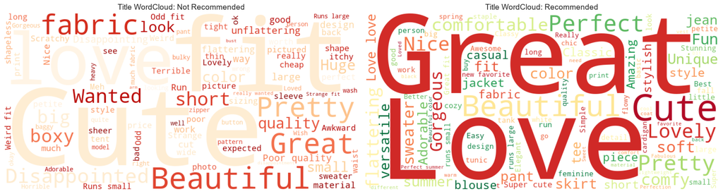

```python
fig, axes = plt.subplots(1, 2, figsize=(18, 7))

for i, (label, val) in enumerate([(0, 'Not Recommended'), (1, 'Recommended')]):
    text = ' '.join(df[df['Recommended IND'] == label]['Title'].astype(str))
    wc = WordCloud(
        width=800, height=400,
        background_color='white',
        stopwords=stopwords,
        max_words=100,
        colormap='RdYlGn' if label == 1 else 'OrRd',
        random_state=42
    ).generate(text)
    axes[i].imshow(wc, interpolation='bilinear')
    axes[i].set_title(f'Title WordCloud: {val}', fontsize=14)
    axes[i].axis('off')

plt.tight_layout()
plt.show()
```

### Top Unigrams (single words)

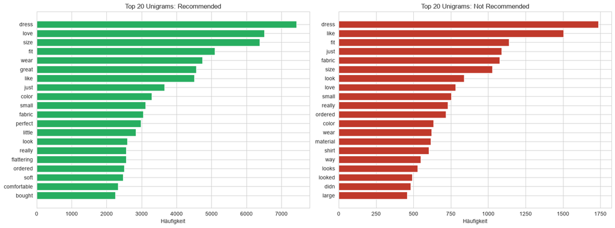

```python
from sklearn.feature_extraction.text import CountVectorizer

def get_top_ngrams(corpus, n_gram_range=(1, 1), top_n=15):
    vec = CountVectorizer(
        ngram_range=n_gram_range,
        stop_words='english',
        max_features=5000
    ).fit(corpus)
    bag = vec.transform(corpus)
    sum_words = bag.sum(axis=0)
    words_freq = [(word, sum_words[0, idx]) for word, idx in vec.vocabulary_.items()]
    return sorted(words_freq, key=lambda x: x[1], reverse=True)[:top_n]

fig, axes = plt.subplots(1, 2, figsize=(16, 6))

for i, (label, val, color) in enumerate([
    (1, 'Recommended', '#27ae60'),
    (0, 'Not Recommended', '#c0392b')
]):
    corpus = df[df['Recommended IND'] == label]['Review Text'].astype(str).tolist()
    top = get_top_ngrams(corpus, n_gram_range=(1, 1), top_n=20)
    words, counts = zip(*top)
    axes[i].barh(range(len(words)), counts, color=color)
    axes[i].set_yticks(range(len(words)))
    axes[i].set_yticklabels(words)
    axes[i].invert_yaxis()
    axes[i].set_title(f'Top 20 Unigrams: {val}')
    axes[i].set_xlabel('Häufigkeit')

plt.tight_layout()
plt.show()
```

### Top Bigrams (word couples)

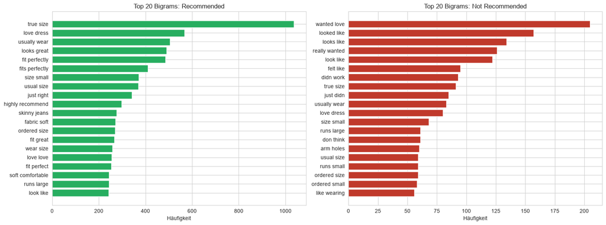

```python
fig, axes = plt.subplots(1, 2, figsize=(16, 6))

for i, (label, val, color) in enumerate([
    (1, 'Recommended', '#27ae60'),
    (0, 'Not Recommended', '#c0392b')
]):
    corpus = df[df['Recommended IND'] == label]['Review Text'].astype(str).tolist()
    top = get_top_ngrams(corpus, n_gram_range=(2, 2), top_n=20)
    words, counts = zip(*top)
    axes[i].barh(range(len(words)), counts, color=color)
    axes[i].set_yticks(range(len(words)))
    axes[i].set_yticklabels(words)
    axes[i].invert_yaxis()
    axes[i].set_title(f'Top 20 Bigrams: {val}')
    axes[i].set_xlabel('Häufigkeit')

plt.tight_layout()
plt.show()
```

### Top Trigrams (group of 3)

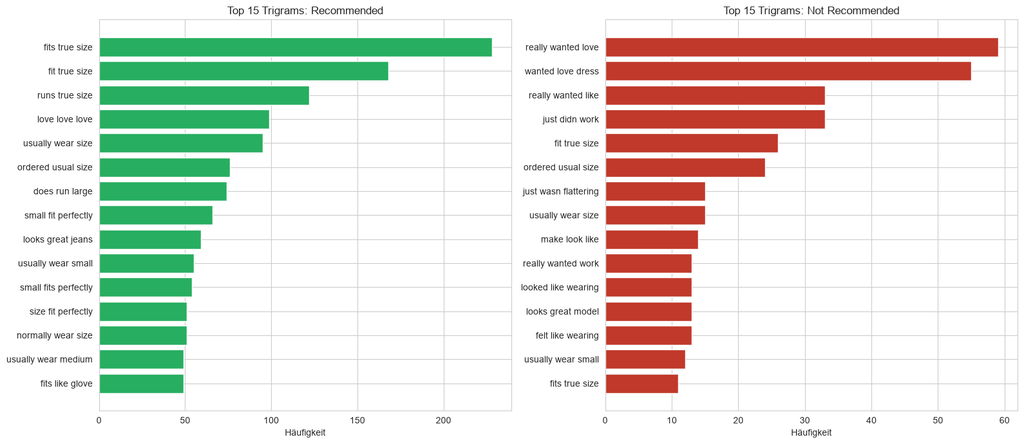

```python
fig, axes = plt.subplots(1, 2, figsize=(16, 7))

for i, (label, val, color) in enumerate([
    (1, 'Recommended', '#27ae60'),
    (0, 'Not Recommended', '#c0392b')

]):
    corpus = df[df['Recommended IND'] == label]['Review Text'].astype(str).tolist()
    top = get_top_ngrams(corpus, n_gram_range=(3, 3), top_n=15)
    words, counts = zip(*top)
    axes[i].barh(range(len(words)), counts, color=color)
    axes[i].set_yticks(range(len(words)))
    axes[i].set_yticklabels(words)
    axes[i].invert_yaxis()
    axes[i].set_title(f'Top 15 Trigrams: {val}')
    axes[i].set_xlabel('Häufigkeit')

plt.tight_layout()
plt.show()
```

### Text-Insights Summary

```python
print("=" * 60)
print("TEXT ANALYSIS SUMMARY")
print("=" * 60)

for label, val in [(0, 'Not Recommended'), (1, 'Recommended')]:
    subset = df[df['Recommended IND'] == label]['Review Text'].astype(str)
    word_counts = subset.apply(lambda x: len(x.split()))
    print(f"\n  {val}:")
    print(f"    Review count:           {len(subset)}")
    print(f"    Avg words per review:   {word_counts.mean():.1f}")
    print(f"    Median words:           {word_counts.median():.0f}")
    print(f"    Max words:              {word_counts.max()}")

print("\n" + "=" * 60)
```

```
============================================================
TEXT ANALYSIS SUMMARY
============================================================

  Not Recommended:
    Review count:           3389
    Avg words per review:   63.8
    Median words:           64
    Max words:              111

  Recommended:
    Review count:           15053
    Avg words per review:   62.1
    Median words:           62
    Max words:              115

============================================================
```

## Building Pipeline

### Imports & Setup

```python
import spacy
import pandas as pd
import numpy as np
from sklearn.pipeline import Pipeline
from sklearn.base import BaseEstimator, TransformerMixin
from sklearn.feature_extraction.text import TfidfVectorizer
from sklearn.preprocessing import LabelEncoder, StandardScaler
from scipy.sparse import hstack

# Load spaCy model
nlp = spacy.load('en_core_web_sm', disable=['parser', 'ner'])

print(f"spaCy model loaded: {nlp.meta['name']} ({nlp.meta['version']})")
print(f"Pipeline components: {nlp.pipe_names}")
```

```
spaCy model loaded: core_web_sm (3.8.0)
Pipeline components: ['tok2vec', 'tagger', 'attribute_ruler', 'lemmatizer']
```

### Overview

[output not shown]

### Quick look at raw data before processing

```python
# Sample 5 reviews to track through the pipeline
sample_idx = df.sample(5, random_state=42).index
print("=" * 80)
print("RAW DATA SAMPLE (before preprocessing)")
print("=" * 80)

for i in sample_idx:
    print(f"\n--- Review #{i} ---")
    print(f"  Title:       {df.loc[i, 'Title']}")
    print(f"  Review:      {str(df.loc[i, 'Review Text'])[:150]}...")
    print(f"  Recommended: {df.loc[i, 'Recommended IND']}")
```

```
================================================================================
RAW DATA SAMPLE (before preprocessing)
================================================================================

--- Review #4983 ---
  Title:       This top is so soft...
  Review:      This top is so soft and with a henley neck opening and longer ribbed shirttail hems, it not only feels heavenly against the skin but it gives off a ca...
  Recommended: 1

--- Review #2054 ---
  Title:       New favorite brand of yoga pants
  Review:      Delighted with these. made in the usa was a big selling factor. great quality and fit. will look out for more active wear from this brand....
  Recommended: 1

--- Review #11160 ---
  Title:       Love this coat!
  Review:      It was bit on pricey side but it was love at first sight! i couldn't let go after i tried it on..it is soft, lightweight, moves with me, keeps me warm...
  Recommended: 1

--- Review #15617 ---
  Title:       Nice flowy summer tank
  Review:      I just got this tank and love it. it has the perfect amount of swing, but does run a little large. the underlay was more yellow than i expected, but i...
  Recommended: 1

--- Review #10454 ---
  Title:       Cute, but...
  Review:      Very lovely sweater - lightweight with cute detailing at the side of the waist, sweet but not saccharine bow at the back of the neck. i really wanted ...
  Recommended: 0
```

### Step 1 – Handle Missing Values

```python
print("=== STEP 1: Handle Missing Values ===\n")

# Before
print("Missing values BEFORE:")
print(df[['Title', 'Review Text']].isnull().sum())
print(f"Total rows: {len(df)}")

# Fill missing text with empty string
df['Title'] = df['Title'].fillna('')
df['Review Text'] = df['Review Text'].fillna('')

# After
print("\nMissing values AFTER:")
print(df[['Title', 'Review Text']].isnull().sum())
```

```
=== STEP 1: Handle Missing Values ===

Missing values BEFORE:
Title          0
Review Text    0
dtype: int64
Total rows: 18442

Missing values AFTER:
Title          0
Review Text    0
dtype: int64
```

### Step 2 – Combine Text Fields

```python
print("=== STEP 2: Combine Title + Review Text ===\n")

df['combined_text'] = df['Title'].astype(str) + ' ' + df['Review Text'].astype(str)
df['combined_text'] = df['combined_text'].str.strip()

# Show sample
for i in sample_idx[:3]:
    print(f"--- Review #{i} ---")
    print(f"  Title:         {df.loc[i, 'Title'][:80]}")
    print(f"  Review:        {df.loc[i, 'Review Text'][:80]}...")
    print(f"  Combined:      {df.loc[i, 'combined_text'][:120]}...")
    print()
```

```
=== STEP 2: Combine Title + Review Text ===

--- Review #4983 ---
  Title:         This top is so soft...
  Review:        This top is so soft and with a henley neck opening and longer ribbed shirttail h...
  Combined:      This top is so soft... This top is so soft and with a henley neck opening and longer ribbed shirttail hems, it not only ...

--- Review #2054 ---
  Title:         New favorite brand of yoga pants
  Review:        Delighted with these. made in the usa was a big selling factor. great quality an...
  Combined:      New favorite brand of yoga pants Delighted with these. made in the usa was a big selling factor. great quality and fit. ...

--- Review #11160 ---
  Title:         Love this coat!
  Review:        It was bit on pricey side but it was love at first sight! i couldn't let go afte...
  Combined:      Love this coat! It was bit on pricey side but it was love at first sight! i couldn't let go after i tried it on..it is s...
```

### Step 3 – spaCy Text Preprocessing (Lowercasing, Lemmatization, Stopword & Punctuation Removal)

```python
print("=== STEP 3: spaCy NLP Preprocessing ===\n")
print("Steps: lowercase → tokenize → remove stopwords & punctuation → lemmatize\n")

def preprocess_spacy(texts, nlp, batch_size=1000):
    """Process texts through spaCy pipeline: lemmatize, remove stopwords & punctuation."""
    processed = []
    for doc in nlp.pipe(texts, batch_size=batch_size, n_process=1):
        tokens = [
            token.lemma_.lower()
            for token in doc
            if not token.is_stop
            and not token.is_punct
            and not token.is_space
            and len(token.text) > 1  # remove single characters
        ]
        processed.append(' '.join(tokens))
    return processed

# Process (takes ~2 min - depending on dataset size)
print("Processing... (this may take ~2min)")
df['processed_text'] = preprocess_spacy(df['combined_text'].tolist(), nlp)
print("Done!")
print(f"Processed {len(df)} reviews.")
```

[output not shown]

### Step 3.1 – Show Before vs After

```python
print("=== BEFORE vs AFTER: spaCy Preprocessing ===\n")

for i in sample_idx:
    print(f"--- Review #{i} ---")
    print(f"  BEFORE: {df.loc[i, 'combined_text'][:120]}...")
    print(f"  AFTER:  {df.loc[i, 'processed_text'][:120]}...")

    # Token count comparison
    before_len = len(df.loc[i, 'combined_text'].split())
    after_len = len(df.loc[i, 'processed_text'].split())
    reduction = (1 - after_len / max(before_len, 1)) * 100
    print(f"  Tokens: {before_len} → {after_len} ({reduction:.0f}% reduction)")
    print()
```

```
=== BEFORE vs AFTER: spaCy Preprocessing ===

--- Review #4983 ---
  BEFORE: This top is so soft... This top is so soft and with a henley neck opening and longer ribbed shirttail hems, it not only ...
  AFTER:  soft soft henley neck opening long rib shirttail hem feel heavenly skin give casual chic vibe great layer short sweater ...
  Tokens: 105 → 40 (62% reduction)

--- Review #2054 ---
  BEFORE: New favorite brand of yoga pants Delighted with these. made in the usa was a big selling factor. great quality and fit. ...
  AFTER:  new favorite brand yoga pant delight usa big selling factor great quality fit look active wear brand...
  Tokens: 32 → 17 (47% reduction)

--- Review #11160 ---
  BEFORE: Love this coat! It was bit on pricey side but it was love at first sight! i couldn't let go after i tried it on..it is s...
  AFTER:  love coat bit pricey love sight let try soft lightweight move keep warm up) feel silky touch versatile stylish run true ...
  Tokens: 65 → 25 (62% reduction)

--- Review #15617 ---
  BEFORE: Nice flowy summer tank I just got this tank and love it. it has the perfect amount of swing, but does run a little large...
  AFTER:  nice flowy summer tank get tank love perfect swing run little large underlay yellow expect think add nice brightness sum...
  Tokens: 52 → 21 (60% reduction)

--- Review #10454 ---
  BEFORE: Cute, but... Very lovely sweater - lightweight with cute detailing at the side of the waist, sweet but not saccharine bo...
  AFTER:  cute lovely sweater lightweight cute detail waist sweet saccharine bow neck want love sweater look um pille arm get wear...
  Tokens: 60 → 23 (62% reduction)
```

### Step 3.2 – Visualize Token Reduction

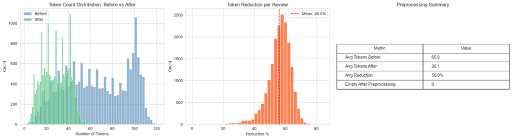

```python
df['tokens_before'] = df['combined_text'].apply(lambda x: len(x.split()))
df['tokens_after'] = df['processed_text'].apply(lambda x: len(x.split()))
df['token_reduction'] = (1 - df['tokens_after'] / df['tokens_before'].clip(lower=1)) * 100

fig, axes = plt.subplots(1, 3, figsize=(18, 5))

# Before vs After distribution
axes[0].hist(df['tokens_before'], bins=50, alpha=0.6, color='steelblue', label='Before', edgecolor='white')
axes[0].hist(df['tokens_after'], bins=50, alpha=0.6, color='#27ae60', label='After', edgecolor='white')
axes[0].set_title('Token Count Distribution: Before vs After')
axes[0].set_xlabel('Number of Tokens')
axes[0].set_ylabel('Count')
axes[0].legend()

# Reduction percentage
axes[1].hist(df['token_reduction'], bins=40, color='coral', edgecolor='white')
axes[1].axvline(df['token_reduction'].mean(), color='red', linestyle='--',
                label=f"Mean: {df['token_reduction'].mean():.1f}%")
axes[1].set_title('Token Reduction per Review')
axes[1].set_xlabel('Reduction %')
axes[1].set_ylabel('Count')
axes[1].legend()

# Summary stats
stats_data = {
    'Metric': ['Avg Tokens Before', 'Avg Tokens After', 'Avg Reduction', 'Empty After Preprocessing'],
    'Value': [
        f"{df['tokens_before'].mean():.1f}",
        f"{df['tokens_after'].mean():.1f}",
        f"{df['token_reduction'].mean():.1f}%",
        f"{(df['tokens_after'] == 0).sum()}"
    ]
}
axes[2].axis('off')
table = axes[2].table(
    cellText=list(zip(stats_data['Metric'], stats_data['Value'])),
    colLabels=['Metric', 'Value'],
    cellLoc='left', loc='center'
)
table.auto_set_font_size(False)
table.set_fontsize(11)
table.scale(1.2, 1.8)
axes[2].set_title('Preprocessing Summary')

plt.tight_layout()
plt.show()

# Cleanup
df.drop(columns=['tokens_before', 'tokens_after', 'token_reduction'], inplace=True)
```

### Step 4 – POS Tag Analysis (what did spaCy keep?)

```python
print("=== STEP 4: POS Tag Analysis (what remains after preprocessing?) ===\n")

# Count POS tags in ONE pass on original text
pos_original = {}
pos_kept = {}

for doc in nlp.pipe(df['combined_text'].head(2000).tolist(), batch_size=500):
    for token in doc:
        pos = token.pos_
        pos_original[pos] = pos_original.get(pos, 0) + 1

        if (not token.is_stop
            and not token.is_punct
            and not token.is_space
            and len(token.text) > 1):
            pos_kept[pos] = pos_kept.get(pos, 0) + 1

# Build DataFrame
all_pos = sorted(set(list(pos_original.keys()) + list(pos_kept.keys())))
pos_df = pd.DataFrame({
    'POS Tag': all_pos,
    'Count Original': [pos_original.get(p, 0) for p in all_pos],
    'Count Kept': [pos_kept.get(p, 0) for p in all_pos]
})

pos_df['Removed'] = pos_df['Count Original'] - pos_df['Count Kept']
pos_df['Kept % raw'] = pos_df['Count Kept'] / pos_df['Count Original'].clip(lower=1) * 100
pos_df['Kept %'] = pos_df['Kept % raw'].apply(
    lambda x: '< 0.1' if 0 < x < 0.1 else ('0.0' if x == 0 else f'{x:.1f}')
)
pos_df = pos_df.sort_values('Count Kept', ascending=False).reset_index(drop=True)

# Add descriptions
pos_df['Category'] = pos_df['POS Tag'].map({
    'NOUN': 'Noun', 'ADJ': 'Adjective', 'VERB': 'Verb', 'ADV': 'Adverb',
    'PROPN': 'Proper Noun', 'NUM': 'Numeral', 'ADP': 'Adposition (Preposition)',
    'AUX': 'Auxiliary Verb', 'PRON': 'Pronoun', 'DET': 'Determiner',
    'CCONJ': 'Coordinating Conjunction', 'SCONJ': 'Subordinating Conjunction',
    'PART': 'Particle', 'INTJ': 'Interjection', 'SYM': 'Symbol',
    'PUNCT': 'Punctuation', 'SPACE': 'Whitespace', 'X': 'Other / Unknown'
}).fillna('Unknown')

pos_df['Examples (Reviews)'] = pos_df['POS Tag'].map({
    'NOUN': 'dress, fabric, size, color, fit',
    'ADJ': 'beautiful, soft, tight, flattering',
    'VERB': 'love, fit, return, buy, wear',
    'ADV': 'very, really, well, perfectly',
    'PROPN': 'Nordstrom, Anthropologie',
    'NUM': '2, 10, first, xl',
    'ADP': 'in, on, for, with, at',
    'AUX': 'is, was, have, would',
    'PRON': 'I, it, this, my, me',
    'DET': 'the, a, this, every',
    'CCONJ': 'and, but, or',
    'SCONJ': 'because, although, if, when',
    'PART': 'not, to (infinitive)',
    'INTJ': 'wow, oh, yes, please',
    'SYM': '$, %, +, &',
    'PUNCT': '. , ! ? ( )',
    'SPACE': '(whitespace, newlines)',
    'X': '(unrecognized tokens)'
}).fillna('')

# Display table
display(pos_df[['Category', 'POS Tag', 'Examples (Reviews)',
                 'Count Original', 'Count Kept', 'Removed', 'Kept %']])
```

```
=== STEP 4: POS Tag Analysis (what remains after preprocessing?) ===
```

|  | Category | POS Tag | Examples (Reviews) | Count Original | Count Kept | Removed | Kept % |
| --- | --- | --- | --- | --- | --- | --- | --- |
| 0 | Noun | NOUN | dress, fabric, size, color, fit | 23966 | 22093 | 1873 | 92.2 |
| 1 | Adjective | ADJ | beautiful, soft, tight, flattering | 15815 | 14487 | 1328 | 91.6 |
| 2 | Verb | VERB | love, fit, return, buy, wear | 14986 | 13658 | 1328 | 91.1 |
| 3 | Adverb | ADV | very, really, well, perfectly | 10183 | 3333 | 6850 | 32.7 |
| 4 | Proper Noun | PROPN | Nordstrom, Anthropologie | 1417 | 1315 | 102 | 92.8 |
| 5 | Numeral | NUM | 2, 10, first, xl | 1995 | 1151 | 844 | 57.7 |
| 6 | Adposition (Preposition) | ADP | in, on, for, with, at | 12115 | 523 | 11592 | 4.3 |
| 7 | Interjection | INTJ | wow, oh, yes, please | 171 | 119 | 52 | 69.6 |
| 8 | Other / Unknown | X | (unrecognized tokens) | 95 | 51 | 44 | 53.7 |
| 9 | Coordinating Conjunction | CCONJ | and, but, or | 7172 | 26 | 7146 | 0.4 |
| 10 | Auxiliary Verb | AUX | is, was, have, would | 11882 | 21 | 11861 | 0.2 |
| 11 | Subordinating Conjunction | SCONJ | because, although, if, when | 2111 | 17 | 2094 | 0.8 |
| 12 | Punctuation | PUNCT | . , ! ? ( ) | 17922 | 15 | 17907 | < 0.1 |
| 13 | Particle | PART | not, to (infinitive) | 3669 | 13 | 3656 | 0.4 |
| 14 | Pronoun | PRON | I, it, this, my, me | 15176 | 12 | 15164 | < 0.1 |
| 15 | Determiner | DET | the, a, this, every | 15705 | 7 | 15698 | < 0.1 |
| 16 | Symbol | SYM | $, %, +, & | 315 | 0 | 315 | 0.0 |
| 17 | Whitespace | SPACE | (whitespace, newlines) | 627 | 0 | 627 | 0.0 |

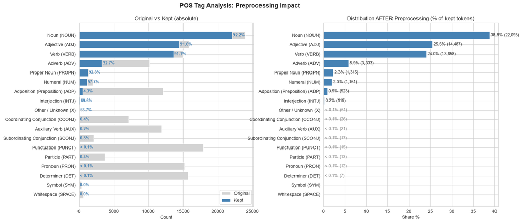

```
Total tokens: 155,322 → 56,841 (36.6% kept)
Nouns + Adjectives make up 64.4% of remaining tokens
```

```python
# --- Plot ---
fig, (ax1, ax2) = plt.subplots(1, 2, figsize=(18, 7))

y = range(len(pos_df))
labels = pos_df['Category'] + ' (' + pos_df['POS Tag'] + ')'

# --- Plot 1: Original vs Kept (absolute) ---
ax1.barh(y, pos_df['Count Original'], color='lightgray', label='Original')
ax1.barh(y, pos_df['Count Kept'], color='steelblue', label='Kept')
ax1.set_yticks(y)
ax1.set_yticklabels(labels)
ax1.invert_yaxis()
ax1.set_title('Original vs Kept (absolute)')
ax1.set_xlabel('Count')
ax1.legend(loc='lower right')

for i, (kept, pct) in enumerate(zip(pos_df['Count Kept'], pos_df['Kept %'])):
    ax1.text(kept + 100, i, f'{pct}%', va='center', fontsize=9,
             color='steelblue', fontweight='bold')

# --- Plot 2: New distribution (share of kept tokens) ---
total_kept = pos_df['Count Kept'].sum()
pos_df['Share %'] = pos_df['Count Kept'] / total_kept * 100

bars = ax2.barh(y, pos_df['Share %'], color='steelblue')
ax2.set_yticks(y)
ax2.set_yticklabels(labels)
ax2.invert_yaxis()
ax2.set_title('Distribution AFTER Preprocessing (% of kept tokens)')
ax2.set_xlabel('Share %')

for i, (share, count) in enumerate(zip(pos_df['Share %'], pos_df['Count Kept'])):
    if share >= 0.1:
        ax2.text(share + 0.3, i, f'{share:.1f}% ({count:,})', va='center', fontsize=9)
    elif count > 0:
        ax2.text(share + 0.3, i, f'< 0.1% ({count:,})', va='center', fontsize=9, color='gray')

fig.suptitle('POS Tag Analysis: Preprocessing Impact', fontsize=14, fontweight='bold', y=1.02)
fig.subplots_adjust(left=0.22, right=0.95, top=0.93, wspace=0.4)
plt.show()

print(f"\nTotal tokens: {pos_df['Count Original'].sum():,} → {total_kept:,} "
      f"({total_kept / pos_df['Count Original'].sum():.1%} kept)")
print(f"Nouns + Adjectives make up {pos_df[pos_df['POS Tag'].isin(['NOUN', 'ADJ'])]['Share %'].sum():.1f}% "
      f"of remaining tokens")
```

### Step 5 – NER Analysis (optional insight)

```python
print("=== STEP 5: Named Entity Recognition (NER) ===\n")

# Re-enable NER temporarily
nlp_ner = spacy.load('en_core_web_sm')

ner_counts = {}
ner_examples = {}  # collect actual examples per entity type

for doc in nlp_ner.pipe(df['Review Text'].head(2000).astype(str).tolist(), batch_size=500):
    for ent in doc.ents:
        ner_counts[ent.label_] = ner_counts.get(ent.label_, 0) + 1
        # Collect up to 5 unique examples per type
        if ent.label_ not in ner_examples:
            ner_examples[ent.label_] = set()
        if len(ner_examples[ent.label_]) < 5:
            ner_examples[ent.label_].add(ent.text.strip())

ner_df = pd.DataFrame(
    sorted(ner_counts.items(), key=lambda x: x[1], reverse=True),
    columns=['Entity Type', 'Count']
)

# What is this entity type?
ner_df['Description'] = ner_df['Entity Type'].map({
    'CARDINAL': 'Cardinal number (no unit)',
    'ORDINAL': 'Ordinal number (ranking/position)',
    'DATE': 'Absolute or relative date',
    'ORG': 'Organization / Company',
    'PERSON': 'Person name',
    'GPE': 'Geopolitical entity (country, city)',
    'NORP': 'Nationality / Religious / Political group',
    'MONEY': 'Monetary value',
    'QUANTITY': 'Measurement / Weight / Distance',
    'TIME': 'Time of day',
    'PERCENT': 'Percentage value',
    'PRODUCT': 'Product (vehicles, software, etc.)',
    'WORK_OF_ART': 'Title of book, song, etc.',
    'FAC': 'Facility (building, airport, etc.)',
    'EVENT': 'Named event',
    'LOC': 'Non-GPE location (mountain, river)',
    'LAW': 'Named law or regulation',
    'LANGUAGE': 'Named language'
}).fillna('Other')

# Generic examples (textbook examples)
ner_df['Generic Examples'] = ner_df['Entity Type'].map({
    'CARDINAL': '5, hundred, 3.5 million',
    'ORDINAL': 'first, second, 3rd',
    'DATE': 'yesterday, June 2024, two weeks ago',
    'ORG': 'Apple, United Nations, BMW',
    'PERSON': 'John Smith, Angela Merkel',
    'GPE': 'Germany, New York, Paris',
    'NORP': 'American, Christian, Republican',
    'MONEY': '$50, 100 euros, five dollars',
    'QUANTITY': '10 kg, 6 feet, 100 miles',
    'TIME': 'morning, 3:00 PM, tonight',
    'PERCENT': '25%, ten percent',
    'PRODUCT': 'iPhone, Boeing 747',
    'WORK_OF_ART': 'Mona Lisa, Harry Potter',
    'FAC': 'JFK Airport, Golden Gate Bridge',
    'EVENT': 'Olympics, World War II',
    'LOC': 'Mount Everest, Pacific Ocean',
    'LAW': 'GDPR, First Amendment',
    'LANGUAGE': 'English, French, Mandarin'
}).fillna('')

# Actual examples from reviews
ner_df['Found in Reviews'] = ner_df['Entity Type'].map({
    etype: ', '.join(sorted(examples))
    for etype, examples in ner_examples.items()
})

display(ner_df[['Entity Type', 'Description', 'Generic Examples', 'Found in Reviews', 'Count']])

del nlp_ner
```

```
=== STEP 5: Named Entity Recognition (NER) ===
```

|  | Entity Type | Description | Generic Examples | Found in Reviews | Count |
| --- | --- | --- | --- | --- | --- |
| 0 | CARDINAL | Cardinal number (no unit) | 5, hundred, 3.5 million | 0p, 125, 2/4, 3, half | 1180 |
| 1 | DATE | Absolute or relative date | yesterday, June 2024, two weeks ago | 5'1, 5'4, christmas, this year, weeks | 615 |
| 2 | ORDINAL | Ordinal number (ranking/position) | first, second, 3rd | First, fifth, first, second, third | 162 |
| 3 | ORG | Organization / Company | Apple, United Nations, BMW | cardi w/ 3/4, hte, navy, ref, wi | 94 |
| 4 | QUANTITY | Measurement / Weight / Distance | 10 kg, 6 feet, 100 miles | 100 degrees, 140 pounds, a full 2 inches, a to... | 85 |
| 5 | MONEY | Monetary value | $50, 100 euros, five dollars | 100#, 120#, 128#, 150, 34b cup | 84 |
| 6 | PERSON | Person name | John Smith, Angela Merkel | Ii'm, Ranna, denim jacket, hte xs, jean jacket | 57 |
| 7 | GPE | Geopolitical entity (country, city) | Germany, New York, Paris | china, france, houston, italy, l | 55 |
| 8 | TIME | Time of day | morning, 3:00 PM, tonight | Last minute, a chilly night, a few hours, an h... | 52 |
| 9 | PERCENT | Percentage value | 25%, ten percent | 100%, 15%, 20%, 30%, the 40% | 23 |
| 10 | NORP | Nationality / Religious / Political group | American, Christian, Republican | d., ejans, french, huge--, reese | 21 |
| 11 | WORK_OF_ART | Title of book, song, etc. | Mona Lisa, Harry Potter | Love | 7 |
| 12 | LOC | Non-GPE location (mountain, river) | Mount Everest, Pacific Ocean | arctic, europe, l, northern california fall/wi... | 5 |
| 13 | PRODUCT | Product (vehicles, software, etc.) | iPhone, Boeing 747 | 0-2/xs, Classic, macintosh | 4 |
| 14 | FAC | Facility (building, airport, etc.) | JFK Airport, Golden Gate Bridge | the denver store | 1 |
| 15 | LANGUAGE | Named language | English, French, Mandarin | english | 1 |

```python
print("\n=== NER CONCLUSION ===")
print("")
print("==> It seems that spaCy's NER is detecting not correctly in this domain, e.g.:\n"
       "       '34b cup' as MONEY \n"
       "       'XS' as ORG \n"
       "       'denim jacket' as PERSON \n"
       "       'a chilly night' as TIME \n"
       )
```

```
=== NER CONCLUSION ===

==> It seems that spaCy's NER is detecting not correctly in this domain, e.g.:
       '34b cup' as MONEY
       'XS' as ORG
       'denim jacket' as PERSON
       'a chilly night' as TIME
```

### Step 6 – Feature Engineering Summary

```python
print("=== STEP 6: Feature Engineering Overview ===\n")

print("Text Features (will be TF-IDF vectorized in Training Pipeline):")
print(f"  • processed_text: spaCy-cleaned, lemmatized review text")
print(f"  • Sample: '{df['processed_text'].iloc[0][:80]}...'\n")

print("Categorical Features (will be label-encoded):")
for col in ['Division Name', 'Department Name', 'Class Name']:
    print(f"  • {col}: {df[col].nunique()} unique values → {df[col].value_counts().head(3).to_dict()}")

print(f"\nNumerical Features (will be scaled):")
for col in ['Age', 'Positive Feedback Count']:
    print(f"  • {col}: mean={df[col].mean():.1f}, std={df[col].std():.1f}")

print(f"\nTarget:")
print(f"  • Recommended IND: {df['Recommended IND'].mean():.1%} positive (imbalanced)")

print("\n" + "=" * 60)
print("PREPROCESSING COMPLETE – Ready for Training Pipeline")
print("=" * 60)
```

```
=== STEP 6: Feature Engineering Overview ===

Text Features (will be TF-IDF vectorized in Training Pipeline):
  • processed_text: spaCy-cleaned, lemmatized review text
  • Sample: 'major design flaw high hope dress want work initially order petite small usual s...'

Categorical Features (will be label-encoded):
  • Division Name: 2 unique values → {'General': 11664, 'General Petite': 6778}
  • Department Name: 6 unique values → {'Tops': 8713, 'Dresses': 5371, 'Bottoms': 3184}
  • Class Name: 14 unique values → {'Dresses': 5371, 'Knits': 3981, 'Blouses': 2587}

Numerical Features (will be scaled):
  • Age: mean=43.4, std=12.2
  • Positive Feedback Count: mean=2.7, std=5.9

Target:
  • Recommended IND: 81.6% positive (imbalanced)

============================================================
PREPROCESSING COMPLETE – Ready for Training Pipeline
============================================================
```

## Training Pipeline

### Imports & Setup

```python
import pandas as pd
import numpy as np
import matplotlib.pyplot as plt
import seaborn as sns
from time import time

# Sklearn: Pipeline & Preprocessing
from sklearn.pipeline import Pipeline
from sklearn.compose import ColumnTransformer
from sklearn.base import BaseEstimator, TransformerMixin
from sklearn.feature_extraction.text import TfidfVectorizer
from sklearn.preprocessing import LabelEncoder, StandardScaler
from scipy.sparse import hstack

# Sklearn: Models
from sklearn.linear_model import LogisticRegression
from sklearn.ensemble import RandomForestClassifier, GradientBoostingClassifier
from sklearn.svm import LinearSVC
from sklearn.naive_bayes import MultinomialNB

# Sklearn: Evaluation
from sklearn.model_selection import train_test_split, cross_val_score, StratifiedKFold
from sklearn.metrics import (
    classification_report, confusion_matrix, ConfusionMatrixDisplay,
    accuracy_score, f1_score, roc_auc_score, roc_curve
)

import warnings
warnings.filterwarnings('ignore')

print("All imports loaded.")
```

```
All imports loaded.
```

### OVERVIEW - Step-by-Step

| Step | What |
| --- | --- |
| 1 | Prepare Features & Target |
| 2 | Train / Test Split |
| 3 | TF-IDF Vectorization |
| 4 | Encode Categorical & Scale Numerical Features |
| 5 | Combine All Features |
| 6 | Baseline Model Comparison (Cross-Validation) |
| 7 | Visualize Model Comparison |
| 8 | Train Best Model & Evaluate on Test Set |
| 9 | Confusion Matrix & ROC Curve |
| 10 | Feature Importance (Top Words) |
| 11 | Training Pipeline Summary |
| 12 | **Full-Scale Pipeline** |

### STEP 1 - Prepare Features & Target

```python
print("=== STEP 1: Prepare Features & Target ===\n")

# Target
y = df['Recommended IND']

# Text feature (from preprocessing pipeline)
text_feature = df['processed_text']

# Categorical features
cat_features = df[['Division Name', 'Department Name', 'Class Name']].copy()

# Numerical features
num_features = df[['Age', 'Positive Feedback Count']].copy()

print(f"Target distribution:\n{y.value_counts()}\n")
print(f"Text feature sample:   '{text_feature.iloc[0][:80]}...'")
print(f"Categorical features:  {list(cat_features.columns)}")
print(f"Numerical features:    {list(num_features.columns)}")
```

```
=== STEP 1: Prepare Features & Target ===

Target distribution:
Recommended IND
1    15053
0     3389
Name: count, dtype: int64

Text feature sample:   'major design flaw high hope dress want work initially order petite small usual s...'
Categorical features:  ['Division Name', 'Department Name', 'Class Name']
Numerical features:    ['Age', 'Positive Feedback Count']
```

### STEP 2 - Train / Test Split

```python
print("=== STEP 2: Train / Test Split ===\n")

X_text_train, X_text_test, \
X_cat_train, X_cat_test, \
X_num_train, X_num_test, \
y_train, y_test = train_test_split(
    text_feature, cat_features, num_features, y,
    test_size=0.2, random_state=42, stratify=y
)

print(f"Train set: {len(y_train):,} samples ({y_train.mean():.1%} positive)")
print(f"Test set:  {len(y_test):,} samples ({y_test.mean():.1%} positive)")
print(f"\n→ Stratified split preserves class balance in both sets.")
```

```
=== STEP 2: Train / Test Split ===

Train set: 14,753 samples (81.6% positive)
Test set:  3,689 samples (81.6% positive)

→ Stratified split preserves class balance in both sets.
```

### STEP 3 -TF-IDF Vectorization

```python
print("=== STEP 3: TF-IDF Vectorization ===\n")

tfidf = TfidfVectorizer(
    max_features=10000,
    ngram_range=(1, 2),    # unigrams + bigrams
    min_df=5,              # ignore very rare terms
    max_df=0.95,           # ignore terms in >95% of docs
    sublinear_tf=True      # apply log normalization
)

X_tfidf_train = tfidf.fit_transform(X_text_train)
X_tfidf_test = tfidf.transform(X_text_test)

print(f"TF-IDF matrix (train): {X_tfidf_train.shape}")
print(f"TF-IDF matrix (test):  {X_tfidf_test.shape}")
print(f"Vocabulary size:       {len(tfidf.vocabulary_):,}")

# Top features by IDF score
feature_names = tfidf.get_feature_names_out()
idf_scores = tfidf.idf_
top_idf = pd.DataFrame({'feature': feature_names, 'idf': idf_scores})
print(f"\nTop 10 most discriminative features (highest IDF):")
display(top_idf.sort_values('idf', ascending=False).head(10).reset_index(drop=True))

print(f"\nTop 10 most common features (lowest IDF):")
display(top_idf.sort_values('idf', ascending=True).head(10).reset_index(drop=True))
```

```
=== STEP 3: TF-IDF Vectorization ===

TF-IDF matrix (train): (14753, 10000)
TF-IDF matrix (test):  (3689, 10000)
Vocabulary size:       10,000

Top 10 most discriminative features (highest IDF):
```

|  | feature | idf |
| --- | --- | --- |
| 0 | dress tee | 8.807510 |
| 1 | sticky | 8.807510 |
| 2 | pxxs | 8.807510 |
| 3 | moo | 8.807510 |
| 4 | stain remover | 8.807510 |
| 5 | year version | 8.653359 |
| 6 | popsicle | 8.653359 |
| 7 | leather pant | 8.653359 |
| 8 | rhinestone | 8.653359 |
| 9 | definitely good | 8.653359 |

```
Top 10 most common features (lowest IDF):
```

|  | feature | idf |
| --- | --- | --- |
| 0 | love | 1.875225 |
| 1 | fit | 1.888815 |
| 2 | wear | 2.021358 |
| 3 | size | 2.085281 |
| 4 | look | 2.104322 |
| 5 | dress | 2.118948 |
| 6 | like | 2.243890 |
| 7 | great | 2.263598 |
| 8 | color | 2.266721 |
| 9 | fabric | 2.614466 |

### STEP 4 - Encode Categorical & Scale Numerical Features

```python
print("=== STEP 4: Encode Categorical & Scale Numerical ===\n")

# Label Encode categoricals
label_encoders = {}
X_cat_train_enc = X_cat_train.copy()
X_cat_test_enc = X_cat_test.copy()

for col in cat_features.columns:
    le = LabelEncoder()
    X_cat_train_enc[col] = le.fit_transform(X_cat_train[col].astype(str))
    X_cat_test_enc[col] = le.transform(X_cat_test[col].astype(str))
    label_encoders[col] = le
    print(f"  {col}: {len(le.classes_)} classes → {list(le.classes_)}")

# Scale numerical features
scaler = StandardScaler()
X_num_train_sc = scaler.fit_transform(X_num_train)
X_num_test_sc = scaler.transform(X_num_test)

print(f"\n Numerical features scaled (mean=0, std=1): ")
print(f"  {'Feature':30s} {'Original Mean':>15s} {'Original Std':>15s} {'Scaled Mean':>15s} {'Scaled Std':>15s}")
print(f"  {'-'*30} {'-'*15} {'-'*15} {'-'*15} {'-'*15}")
for i, col in enumerate(num_features.columns):
    print(f"  {col:30s} {X_num_train.iloc[:, i].mean():>15.2f} {X_num_train.iloc[:, i].std():>15.2f}"
          f" {X_num_train_sc[:, i].mean():>15.4f} {X_num_train_sc[:, i].std():>15.4f}")
```

```
=== STEP 4: Encode Categorical & Scale Numerical ===

  Division Name: 2 classes → ['General', 'General Petite']
  Department Name: 6 classes → ['Bottoms', 'Dresses', 'Intimate', 'Jackets', 'Tops', 'Trend']
  Class Name: 14 classes → ['Blouses', 'Casual bottoms', 'Dresses', 'Fine gauge', 'Jackets', 'Jeans', 'Knits', 'Lounge', 'Outerwear', 'Pants', 'Shorts', 'Skirts', 'Sweaters', 'Trend']

 Numerical features scaled (mean=0, std=1):
  Feature                          Original Mean    Original Std     Scaled Mean      Scaled Std
  ------------------------------ --------------- --------------- --------------- ---------------
  Age                                      43.42           12.28          0.0000          1.0000
  Positive Feedback Count                   2.70            6.04          0.0000          1.0000
```

### STEP 5 - Combine All Features

```python
print("=== STEP 5: Combine All Features ===\n")

from scipy.sparse import csr_matrix

# Combine: TF-IDF (sparse) + Categorical (dense→sparse) + Numerical (dense→sparse)
X_train = hstack([
    X_tfidf_train,
    csr_matrix(X_cat_train_enc.values),
    csr_matrix(X_num_train_sc)
])

X_test = hstack([
    X_tfidf_test,
    csr_matrix(X_cat_test_enc.values),
    csr_matrix(X_num_test_sc)
])

print(f"Combined feature matrix (train): {X_train.shape}")
print(f"Combined feature matrix (test):  {X_test.shape}")
print(f"\nFeature breakdown:")
print(f"  TF-IDF:       {X_tfidf_train.shape[1]:,} features")
print(f"  Categorical:  {X_cat_train_enc.shape[1]} features")
print(f"  Numerical:    {X_num_train_sc.shape[1]} features")
print(f"  Total:        {X_train.shape[1]:,} features")
```

```
=== STEP 5: Combine All Features ===

Combined feature matrix (train): (14753, 10005)
Combined feature matrix (test):  (3689, 10005)

Feature breakdown:
  TF-IDF:       10,000 features
  Categorical:  3 features
  Numerical:    2 features
  Total:        10,005 features
```

### STEP 6 - Baseline Model Comparison (Cross-Validation)

```python
print("=== STEP 6: Model Comparison (5-Fold Cross-Validation) ===\n")

models = {
    'Logistic Regression': LogisticRegression(max_iter=1000, random_state=42),
    'Naive Bayes': MultinomialNB(),
    'Linear SVC': LinearSVC(max_iter=2000, random_state=42),
    'Random Forest': RandomForestClassifier(n_estimators=200, random_state=42, n_jobs=-1),
    'Gradient Boosting': GradientBoostingClassifier(n_estimators=200, random_state=42)
}

cv = StratifiedKFold(n_splits=5, shuffle=True, random_state=42)
results = []

for name, model in models.items():
    start = time()

    # Naive Bayes needs non-negative input → use only TF-IDF
    if name == 'Naive Bayes':
        scores = cross_val_score(model, X_tfidf_train, y_train, cv=cv, scoring='f1', n_jobs=-1)
    else:
        scores = cross_val_score(model, X_train, y_train, cv=cv, scoring='f1', n_jobs=-1)

    elapsed = time() - start
    results.append({
        'Model': name,
        'F1 Mean': scores.mean(),
        'F1 Std': scores.std(),
        'Time (s)': elapsed
    })
    print(f"  {name:25s} → F1: {scores.mean():.4f} (± {scores.std():.4f})  [{elapsed:.1f}s]")

results_df = pd.DataFrame(results).sort_values('F1 Mean', ascending=False).reset_index(drop=True)

print("\n" + "=" * 60)
display(results_df)
```

```
=== STEP 6: Model Comparison (5-Fold Cross-Validation) ===

  Logistic Regression       → F1: 0.9358 (± 0.0038)  [7.7s]
  Naive Bayes               → F1: 0.9179 (± 0.0022)  [4.5s]
  Linear SVC                → F1: 0.9374 (± 0.0051)  [5.2s]
  Random Forest             → F1: 0.9251 (± 0.0024)  [12.4s]
  Gradient Boosting         → F1: 0.9292 (± 0.0019)  [22.5s]

============================================================
```

|  | Model | F1 Mean | F1 Std | Time (s) |
| --- | --- | --- | --- | --- |
| 0 | Linear SVC | 0.937419 | 0.005128 | 5.180472 |
| 1 | Logistic Regression | 0.935811 | 0.003827 | 7.683351 |
| 2 | Gradient Boosting | 0.929191 | 0.001869 | 22.535723 |
| 3 | Random Forest | 0.925092 | 0.002412 | 12.362444 |
| 4 | Naive Bayes | 0.917937 | 0.002246 | 4.480341 |

### STEP 7 - Visualize Model Comparison

```
=== STEP 7 - Visualize Model Comparison) ===
```

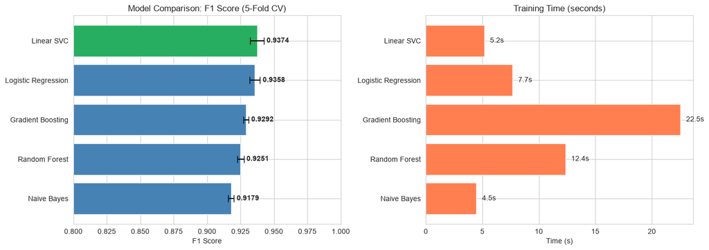

```
→ Best model: Linear SVC (F1: 0.9374)
```

```python
print("=== STEP 7 - Visualize Model Comparison) ===\n")

fig, axes = plt.subplots(1, 2, figsize=(14, 5))

# F1 Score comparison
colors = ['#27ae60' if i == 0 else 'steelblue' for i in range(len(results_df))]
bars = axes[0].barh(results_df['Model'], results_df['F1 Mean'], color=colors,
                     xerr=results_df['F1 Std'], capsize=5)
axes[0].set_title('Model Comparison: F1 Score (5-Fold CV)')
axes[0].set_xlabel('F1 Score')
axes[0].set_xlim(0.8, 1.0)
axes[0].invert_yaxis()
for i, (f1, std) in enumerate(zip(results_df['F1 Mean'], results_df['F1 Std'])):
    axes[0].text(f1 + std + 0.002, i, f'{f1:.4f}', va='center', fontsize=10, fontweight='bold')

# Training time comparison
axes[1].barh(results_df['Model'], results_df['Time (s)'], color='coral')
axes[1].set_title('Training Time (seconds)')
axes[1].set_xlabel('Time (s)')
axes[1].invert_yaxis()
for i, t in enumerate(results_df['Time (s)']):
    axes[1].text(t + 0.5, i, f'{t:.1f}s', va='center', fontsize=10)

plt.tight_layout()
plt.show()

best_model_name = results_df.iloc[0]['Model']
print(f"\n→ Best model: {best_model_name} (F1: {results_df.iloc[0]['F1 Mean']:.4f})")
```

### STEP 8 - Train Best Model & Evaluate on Test Set

```python
print(f"=== STEP 8: Train & Evaluate Best Model ({best_model_name}) ===\n")

# Train on full training set
best_model = models[best_model_name]

if best_model_name == 'Naive Bayes':
    best_model.fit(X_tfidf_train, y_train)
    y_pred = best_model.predict(X_tfidf_test)
    y_proba = best_model.predict_proba(X_tfidf_test)[:, 1]
else:
    best_model.fit(X_train, y_train)
    y_pred = best_model.predict(X_test)
    # LinearSVC has no predict_proba
    if hasattr(best_model, 'predict_proba'):
        y_proba = best_model.predict_proba(X_test)[:, 1]
    else:
        y_proba = best_model.decision_function(X_test)

print("Classification Report:")
print(classification_report(y_test, y_pred, target_names=['Not Recommended', 'Recommended']))

print(f"Accuracy:  {accuracy_score(y_test, y_pred):.4f}")
print(f"F1 Score:  {f1_score(y_test, y_pred):.4f}")
print(f"ROC AUC:   {roc_auc_score(y_test, y_proba):.4f}")
```

```
=== STEP 8: Train & Evaluate Best Model (Linear SVC) ===

Classification Report:
                 precision    recall  f1-score   support

Not Recommended       0.75      0.64      0.69       678
    Recommended       0.92      0.95      0.94      3011

       accuracy                           0.89      3689
      macro avg       0.83      0.80      0.81      3689
   weighted avg       0.89      0.89      0.89      3689

Accuracy:  0.8943
F1 Score:  0.9363
ROC AUC:   0.9275
```

### STEP 9 - Confusion Matrix & ROC Curve

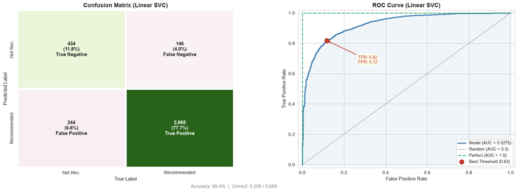

```python
fig, axes = plt.subplots(1, 2, figsize=(16, 6))

# --- Confusion Matrix  ---
cm = confusion_matrix(y_test, y_pred)
cm_t = cm.T
total = cm_t.sum()

# Custom colors: green for correct, red for errors
cm_colors = np.array([
    [cm_t[0,0], -cm_t[0,1]],   # TN, FN
    [-cm_t[1,0], cm_t[1,1]]    # FP, TP
])

# Custom annotation
labels = np.array([
    [f"{cm_t[0,0]:,}\n({cm_t[0,0]/total:.1%})\nTrue Negative",
     f"{cm_t[0,1]:,}\n({cm_t[0,1]/total:.1%})\nFalse Negative"],
    [f"{cm_t[1,0]:,}\n({cm_t[1,0]/total:.1%})\nFalse Positive",
     f"{cm_t[1,1]:,}\n({cm_t[1,1]/total:.1%})\nTrue Positive"]
])

sns.heatmap(
    cm_colors, annot=labels, fmt='', cmap='PiYG', center=0,
    ax=axes[0],
    xticklabels=['Not Rec.', 'Recommended'],
    yticklabels=['Not Rec.', 'Recommended'],
    linewidths=3, linecolor='white',
    cbar=False, annot_kws={'fontsize': 11, 'fontweight': 'bold'}
)
axes[0].set_xlabel('True Label', fontsize=11)
axes[0].set_ylabel('Predicted Label', fontsize=11)
axes[0].set_title(f'Confusion Matrix ({best_model_name})', fontsize=13, fontweight='bold')
axes[0].spines['top'].set_visible(False)
axes[0].spines['right'].set_visible(False)
axes[0].spines['bottom'].set_visible(False)
axes[0].spines['left'].set_visible(False)
axes[0].tick_params(left=False, bottom=False)

# Accuracy annotation
accuracy = (cm_t[0,0] + cm_t[1,1]) / total
axes[0].text(1.0, -0.12,
             f'Accuracy: {accuracy:.1%}  |  Correct: {cm_t[0,0]+cm_t[1,1]:,} / {total:,}',
             ha='center', va='center', fontsize=10, color='gray',
             transform=axes[0].transAxes)

# --- ROC Curve (enhanced) ---
fpr, tpr, thresholds = roc_curve(y_test, y_proba)
auc_score = roc_auc_score(y_test, y_proba)

axes[1].plot(fpr, tpr, color='steelblue', linewidth=2.5, label=f'Model (AUC = {auc_score:.4f})')
axes[1].fill_between(fpr, tpr, alpha=0.08, color='steelblue')
axes[1].plot([0, 1], [0, 1], color='gray', linestyle='--', linewidth=1, label='Random (AUC = 0.5)')
axes[1].plot([0, 0, 1], [0, 1, 1], color='#27ae60', linestyle='--', linewidth=2, alpha=0.8,
             label='Perfect (AUC = 1.0)')

# Best threshold
optimal_idx = np.argmax(tpr - fpr)
axes[1].scatter(fpr[optimal_idx], tpr[optimal_idx], color='#c0392b', s=100, zorder=5,
                label=f'Best Threshold ({thresholds[optimal_idx]:.2f})')
axes[1].annotate(
    f'TPR: {tpr[optimal_idx]:.2f}\nFPR: {fpr[optimal_idx]:.2f}',
    xy=(fpr[optimal_idx], tpr[optimal_idx]),
    xytext=(fpr[optimal_idx] + 0.15, tpr[optimal_idx] - 0.15),
    fontsize=9, color='#c0392b',
    arrowprops=dict(arrowstyle='->', color='#c0392b', lw=1.5),
    bbox=dict(boxstyle='round,pad=0.3', fc='lightyellow', alpha=0.8)
)

axes[1].set_title(f'ROC Curve ({best_model_name})', fontsize=13, fontweight='bold')
axes[1].set_xlabel('False Positive Rate', fontsize=11)
axes[1].set_ylabel('True Positive Rate', fontsize=11)
axes[1].legend(loc='lower right', fontsize=9, framealpha=0.9)
axes[1].set_xlim(-0.02, 1.02)
axes[1].set_ylim(-0.02, 1.02)

plt.tight_layout()
plt.show()
```

### STEP 10 - Feature Importance (Top Words)

```
=== STEP 10: Feature Importance ===
```

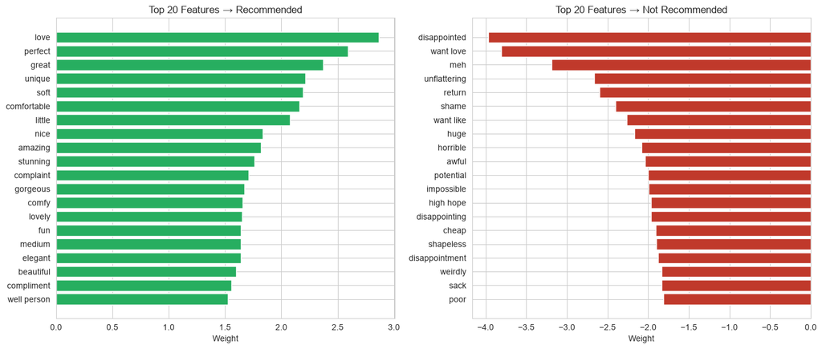

```python
print(f"=== STEP 10: Feature Importance ===\n")

if hasattr(best_model, 'coef_'):
    # For linear models (LogReg, SVC)
    feature_names_all = list(tfidf.get_feature_names_out()) + \
                        list(cat_features.columns) + \
                        list(num_features.columns)

    if best_model_name == 'Naive Bayes':
        coefs = best_model.coef_[0]
        feature_names_all = list(tfidf.get_feature_names_out())
    else:
        coefs = best_model.coef_[0] if len(best_model.coef_.shape) > 1 else best_model.coef_

    coef_df = pd.DataFrame({'feature': feature_names_all[:len(coefs)], 'weight': coefs})

    fig, axes = plt.subplots(1, 2, figsize=(14, 6))

    # Top positive (recommend)
    top_pos = coef_df.nlargest(20, 'weight')
    axes[0].barh(range(len(top_pos)), top_pos['weight'], color='#27ae60')
    axes[0].set_yticks(range(len(top_pos)))
    axes[0].set_yticklabels(top_pos['feature'])
    axes[0].invert_yaxis()
    axes[0].set_title('Top 20 Features → Recommended')
    axes[0].set_xlabel('Weight')

    # Top negative (not recommend)
    top_neg = coef_df.nsmallest(20, 'weight')
    axes[1].barh(range(len(top_neg)), top_neg['weight'], color='#c0392b')
    axes[1].set_yticks(range(len(top_neg)))
    axes[1].set_yticklabels(top_neg['feature'])
    axes[1].invert_yaxis()
    axes[1].set_title('Top 20 Features → Not Recommended')
    axes[1].set_xlabel('Weight')

    plt.tight_layout()
    plt.show()

elif hasattr(best_model, 'feature_importances_'):
    # For tree-based models (RF, GBM)
    feature_names_all = list(tfidf.get_feature_names_out()) + \
                        list(cat_features.columns) + \
                        list(num_features.columns)

    imp_df = pd.DataFrame({
        'feature': feature_names_all,
        'importance': best_model.feature_importances_
    }).nlargest(30, 'importance')

    fig, ax = plt.subplots(figsize=(10, 8))
    ax.barh(range(len(imp_df)), imp_df['importance'], color='steelblue')
    ax.set_yticks(range(len(imp_df)))
    ax.set_yticklabels(imp_df['feature'])
    ax.invert_yaxis()
    ax.set_title('Top 30 Feature Importances')
    ax.set_xlabel('Importance')
    plt.tight_layout()
    plt.show()
```

### STEP 11 - Training Pipeline Summary

```python
print("=" * 60)
print("TRAINING PIPELINE SUMMARY")
print("=" * 60)
print(f"  Best Model:       {best_model_name}")
print(f"  CV F1 Score:      {results_df.iloc[0]['F1 Mean']:.4f} (± {results_df.iloc[0]['F1 Std']:.4f})")
print(f"  Test F1 Score:    {f1_score(y_test, y_pred):.4f}")
print(f"  Test Accuracy:    {accuracy_score(y_test, y_pred):.4f}")
print(f"  Test ROC AUC:     {roc_auc_score(y_test, y_proba):.4f}")
print(f"  Total Features:   {X_train.shape[1]:,}")
print(f"    TF-IDF:         {X_tfidf_train.shape[1]:,}")
print(f"    Categorical:    {X_cat_train_enc.shape[1]}")
print(f"    Numerical:      {X_num_train_sc.shape[1]}")
print(f"  Train Size:       {len(y_train):,}")
print(f"  Test Size:        {len(y_test):,}")
print("=" * 60)
print("\nPipeline Steps:")
print("  1) Train/Test Split (80/20, stratified)")
print("  2) TF-IDF Vectorization (unigrams + bigrams, max 10k features)")
print("  3) Label Encoding (categorical) + StandardScaler (numerical)")
print("  4) Feature Combination (sparse matrix)")
print("  5) 5-Fold Stratified CV (model comparison)")
print("  6) Best model evaluation on held-out test set")
print("  7) Feature importance analysis")
print("=" * 60)
```

```
============================================================
TRAINING PIPELINE SUMMARY
============================================================
  Best Model:       Linear SVC
  CV F1 Score:      0.9374 (± 0.0051)
  Test F1 Score:    0.9363
  Test Accuracy:    0.8943
  Test ROC AUC:     0.9275
  Total Features:   10,005
    TF-IDF:         10,000
    Categorical:    3
    Numerical:      2
  Train Size:       14,753
  Test Size:        3,689
============================================================

Pipeline Steps:
  1) Train/Test Split (80/20, stratified)
  2) TF-IDF Vectorization (unigrams + bigrams, max 10k features)
  3) Label Encoding (categorical) + StandardScaler (numerical)
  4) Feature Combination (sparse matrix)
  5) 5-Fold Stratified CV (model comparison)
  6) Best model evaluation on held-out test set
  7) Feature importance analysis
============================================================
```

### STEP 12 - **Full-Scale Pipeline**

```python
print("=" * 60)
print("RECAP: Manual Training Steps (Cells above)")
print("=" * 60)
print("""
  Step 1:  Prepare Features & Target        → text, categorical, numerical separated
  Step 2:  Train / Test Split               → 80/20, stratified
  Step 3:  TF-IDF Vectorization             → unigrams + bigrams, max 10k features
  Step 4:  Encode Categorical & Scale Num.  → LabelEncoder + StandardScaler
  Step 5:  Combine All Features             → hstack → sparse matrix
  Step 6:  Baseline Model Comparison        → 5-Fold CV (LogReg, NB, SVC, RF, GBM)
  Step 7:  Visualize Model Comparison       → F1 Score + Training Time
  Step 8:  Train Best Model & Evaluate      → Classification Report on test set
  Step 9:  Confusion Matrix & ROC Curve     → Visual evaluation
  Step 10: Feature Importance (Top Words)   → Strongest predictors per class
  Step 11: Training Pipeline Summary        → Final metrics overview

Now: Wrapping all of this into a single sklearn Pipeline object.
     This ensures reproducibility, prevents data leakage,
     and enables hyperparameter tuning via GridSearchCV.
""")
```

```
============================================================
RECAP: Manual Training Steps (Cells above)
============================================================

  Step 1:  Prepare Features & Target        → text, categorical, numerical separated
  Step 2:  Train / Test Split               → 80/20, stratified
  Step 3:  TF-IDF Vectorization             → unigrams + bigrams, max 10k features
  Step 4:  Encode Categorical & Scale Num.  → LabelEncoder + StandardScaler
  Step 5:  Combine All Features             → hstack → sparse matrix
  Step 6:  Baseline Model Comparison        → 5-Fold CV (LogReg, NB, SVC, RF, GBM)
  Step 7:  Visualize Model Comparison       → F1 Score + Training Time
  Step 8:  Train Best Model & Evaluate      → Classification Report on test set
  Step 9:  Confusion Matrix & ROC Curve     → Visual evaluation
  Step 10: Feature Importance (Top Words)   → Strongest predictors per class
  Step 11: Training Pipeline Summary        → Final metrics overview

Now: Wrapping all of this into a single sklearn Pipeline object.
     This ensures reproducibility, prevents data leakage,
     and enables hyperparameter tuning via GridSearchCV.
```

```python
# ══════════════════════════════════════════════════════════════════════════
#  TRAINING PIPELINE
# ══════════════════════════════════════════════════════════════════════════

# ── Imports ──────────────────────────────────────────────────────────────
import spacy
import numpy as np
import pandas as pd
from scipy.sparse import hstack

from sklearn.base import BaseEstimator, TransformerMixin
from sklearn.pipeline import Pipeline
from sklearn.preprocessing import StandardScaler, LabelEncoder
from sklearn.feature_extraction.text import TfidfVectorizer
from sklearn.svm import LinearSVC
from sklearn.calibration import CalibratedClassifierCV
from sklearn.model_selection import train_test_split
from sklearn.metrics import classification_report, accuracy_score, f1_score, roc_auc_score
from sklearn import set_config

TOTAL_STEPS = 3


# ── Step 1: SpacyPreprocessor ───────────────────────────────────────────

class SpacyPreprocessor(BaseEstimator, TransformerMixin):
    """
    All-in-one NLP step:
      - Combine Title + Review Text (handle NaN)
      - spaCy: lowercase, lemmatise, remove stops/punct/short tokens
      - Engineer NLP features: POS counts, text length, word count
    """
    STEP = 1

    def __init__(self, batch_size=500, verbose=True):
        self.batch_size = batch_size
        self.verbose = verbose

    def _log(self, msg):
        if self.verbose:
            print(msg)

    def fit(self, X, y=None):
        self._log(f"\n{'='*60}")
        self._log(f"[Step {self.STEP}/{TOTAL_STEPS}] SpacyPreprocessor – fit")
        self._log(f"  → Loading spaCy model 'en_core_web_sm' ...")
        self.nlp_ = spacy.load("en_core_web_sm", disable=["ner"])
        self._log(f"  → Model loaded (tagger + parser active, NER disabled).")
        return self

    def transform(self, X):
        X = X.copy()

        # ── Handle NaN + combine text ──
        nulls_title  = X["Title"].isna().sum()
        nulls_review = X["Review Text"].isna().sum()
        X["Title"]       = X["Title"].fillna("")
        X["Review Text"] = X["Review Text"].fillna("")
        X["combined_text"] = X["Title"] + " " + X["Review Text"]
        self._log(f"[Step {self.STEP}/{TOTAL_STEPS}] SpacyPreprocessor – transform")
        self._log(f"  → Filled {nulls_title} null titles, {nulls_review} null reviews.")

        # ── spaCy processing ──
        texts = X["combined_text"].astype(str).tolist()
        n = len(texts)
        self._log(f"  → Processing {n} documents ...")

        processed_texts = []
        noun_counts     = []
        verb_counts     = []
        adj_counts      = []
        adv_counts      = []
        text_lengths    = []
        word_counts     = []

        for i, doc in enumerate(self.nlp_.pipe(texts, batch_size=self.batch_size)):
            # Lemmatised + cleaned tokens
            tokens = [
                token.lemma_.lower()
                for token in doc
                if not token.is_stop
                and not token.is_punct
                and not token.is_space
                and len(token.text) > 1
            ]
            processed_texts.append(" ".join(tokens))

            # POS tag counts (on full doc, before filtering)
            noun_counts.append(sum(1 for t in doc if t.pos_ == "NOUN"))
            verb_counts.append(sum(1 for t in doc if t.pos_ == "VERB"))
            adj_counts.append(sum(1 for t in doc if t.pos_ == "ADJ"))
            adv_counts.append(sum(1 for t in doc if t.pos_ == "ADV"))

            # Text statistics
            text_lengths.append(len(doc.text))
            word_counts.append(len([t for t in doc if not t.is_space]))

            if self.verbose and ((i + 1) % 5000 == 0 or (i + 1) == n):
                print(f"    ... {i+1}/{n} documents done ({(i+1)/n*100:.0f}%)")

        X["processed_text"] = processed_texts
        X["noun_count"]     = noun_counts
        X["verb_count"]     = verb_counts
        X["adj_count"]      = adj_counts
        X["adv_count"]      = adv_counts
        X["text_length"]    = text_lengths
        X["word_count"]     = word_counts

        self._log(f"  → Created: processed_text (lemmatised, lowercased, stopwords removed)")
        self._log(f"           + 6 engineered features:")
        self._log(f"    (noun_count, verb_count, adj_count, adv_count,")
        self._log(f"     text_length, word_count)")
        return X


# ── Step 2: FeatureCombiner ─────────────────────────────────────────────
from sklearn.preprocessing import OrdinalEncoder

class CategoricalEncoder(BaseEstimator, TransformerMixin):
    """Encode categoricals; handles unseen labels gracefully."""
    def fit(self, X, y=None):
        self.encoder_ = OrdinalEncoder(
            handle_unknown="use_encoded_value",
            unknown_value=-1,
        )
        self.encoder_.fit(X)
        return self

    def transform(self, X):
        return self.encoder_.transform(X)



class FeatureCombiner(BaseEstimator, TransformerMixin):
    """
    Combine TF-IDF (sparse), encoded categoricals and
    scaled numericals into a single feature matrix.
    """
    STEP = 2

    def __init__(self, tfidf_params=None, cat_cols=None, num_cols=None, verbose=True):
        self.tfidf_params = tfidf_params or {
            "max_features": 10_000,
            "ngram_range": (1, 2),
            "min_df": 5,
            "max_df": 0.95,
            "sublinear_tf": True,
        }
        self.cat_cols = cat_cols or [
            "Division Name", "Department Name", "Class Name"
        ]
        self.num_cols = num_cols or [
            "Age", "Positive Feedback Count",
            "noun_count", "verb_count", "adj_count", "adv_count",
            "text_length", "word_count",
        ]
        self.verbose = verbose

    def _log(self, msg):
        if self.verbose:
            print(msg)

    def fit(self, X, y=None):
        self._log(f"\n{'='*60}")
        self._log(f"[Step {self.STEP}/{TOTAL_STEPS}] FeatureCombiner – fit")

        self.tfidf_     = TfidfVectorizer(**self.tfidf_params)
        self.label_enc_ = CategoricalEncoder()
        self.scaler_    = StandardScaler()

        self._log(f"  → Fitting TF-IDF on 'processed_text' ...")
        self.tfidf_.fit(X["processed_text"])
        self._log(f"    Vocabulary size: {len(self.tfidf_.vocabulary_)}")

        self._log(f"  → Fitting LabelEncoder on {self.cat_cols} ...")
        self.label_enc_.fit(X[self.cat_cols])

        self._log(f"  → Fitting StandardScaler on {self.num_cols} ...")
        self.scaler_.fit(X[self.num_cols])

        self._log(f"  → {TOTAL_STEPS - self.STEP} step(s) remaining.")
        return self

    def transform(self, X):
        self._log(f"[Step {self.STEP}/{TOTAL_STEPS}] FeatureCombiner – transform")
        X_tfidf = self.tfidf_.transform(X["processed_text"])
        self._log(f"  → TF-IDF matrix  : {X_tfidf.shape}")
        X_cat = self.label_enc_.transform(X[self.cat_cols])
        self._log(f"  → Categoricals   : {X_cat.shape}")
        X_num = self.scaler_.transform(X[self.num_cols])
        self._log(f"  → Numericals     : {X_num.shape}")
        combined = hstack([X_tfidf, X_cat, X_num])
        self._log(f"  → Combined matrix: {combined.shape}")
        return combined


# ── Build Pipeline ──────────────────────────────────────────────────────

CAT_COLS = ["Division Name", "Department Name", "Class Name"]
NUM_COLS = [
    "Age", "Positive Feedback Count",
    "noun_count", "verb_count", "adj_count", "adv_count",
    "text_length", "word_count",
]
TFIDF_PARAMS = {
    "max_features": 10_000,
    "ngram_range": (1, 2),
    "min_df": 5,
    "max_df": 0.95,
    "sublinear_tf": True,
}

pipeline = Pipeline([
    ("spacy_preprocessor", SpacyPreprocessor(batch_size=500)),
    ("feature_combiner",   FeatureCombiner(
        tfidf_params=TFIDF_PARAMS,
        cat_cols=CAT_COLS,
        num_cols=NUM_COLS,
    )),
    ("model", CalibratedClassifierCV(
        estimator=LinearSVC(max_iter=2000, random_state=42),
    )),
])

# ── Show Pipeline Structure ──
set_config(display="diagram")
print("Pipeline Structure:")
display(pipeline)

# ── Train / Evaluate ────────────────────────────────────────────────────

X = df.drop(columns=["Recommended IND"])
y = df["Recommended IND"]

X_train, X_test, y_train, y_test = train_test_split(
    X, y, test_size=0.2, random_state=42, stratify=y,
)

print(f"\nTrain size: {len(X_train)}  |  Test size: {len(X_test)}")
print(f"Positive rate – Train: {y_train.mean():.3f}  |  Test: {y_test.mean():.3f}")

print(f"\n{'#'*60}")
print(f"  PIPELINE FIT (Training)")
print(f"{'#'*60}")
pipeline.fit(X_train, y_train)

print(f"\n{'='*60}")
print(f"[Step {TOTAL_STEPS}/{TOTAL_STEPS}] Model (CalibratedClassifierCV + LinearSVC)")
print(f"  → Training complete ✓")

print(f"\n{'#'*60}")
print(f"  PIPELINE PREDICT (Inference on test set)")
print(f"{'#'*60}")
y_pred  = pipeline.predict(X_test)
y_proba = pipeline.predict_proba(X_test)[:, 1]
print(f"  → Inference complete ✓")

print(f"\n{'#'*60}")
print(f"  EVALUATION")
print(f"{'#'*60}\n")
print("Classification Report:")
print(classification_report(y_test, y_pred, target_names=["Not Recommended", "Recommended"]))
print(f"Accuracy : {accuracy_score(y_test, y_pred):.4f}")
print(f"F1 Score : {f1_score(y_test, y_pred):.4f}")
print(f"ROC AUC  : {roc_auc_score(y_test, y_proba):.4f}")
```

```
Pipeline Structure:
```

```
Pipeline(steps=[('spacy_preprocessor', SpacyPreprocessor()),
                ('feature_combiner',
                 FeatureCombiner(cat_cols=['Division Name', 'Department Name',
                                           'Class Name'],
                                 num_cols=['Age', 'Positive Feedback Count',
                                           'noun_count', 'verb_count',
                                           'adj_count', 'adv_count',
                                           'text_length', 'word_count'],
                                 tfidf_params={'max_df': 0.95,
                                               'max_features': 10000,
                                               'min_df': 5,
                                               'ngram_range': (1, 2),
                                               'sublinear_tf': True})),
                ('model',
                 CalibratedClassifierCV(estimator=LinearSVC(max_iter=2000,
                                                            random_state=42)))])
```

```
Train size: 14753  |  Test size: 3689
Positive rate – Train: 0.816  |  Test: 0.816

############################################################
  PIPELINE FIT (Training)
############################################################

============================================================
[Step 1/3] SpacyPreprocessor – fit
  → Loading spaCy model 'en_core_web_sm' ...
  → Model loaded (tagger + parser active, NER disabled).
[Step 1/3] SpacyPreprocessor – transform
  → Filled 0 null titles, 0 null reviews.
  → Processing 14753 documents ...
    ... 5000/14753 documents done (34%)
    ... 10000/14753 documents done (68%)
    ... 14753/14753 documents done (100%)
  → Created: processed_text (lemmatised, lowercased, stopwords removed)
           + 6 engineered features:
    (noun_count, verb_count, adj_count, adv_count,
     text_length, word_count)

============================================================
[Step 2/3] FeatureCombiner – fit
  → Fitting TF-IDF on 'processed_text' ...
    Vocabulary size: 10000
  → Fitting LabelEncoder on ['Division Name', 'Department Name', 'Class Name'] ...
  → Fitting StandardScaler on ['Age', 'Positive Feedback Count', 'noun_count', 'verb_count', 'adj_count', 'adv_count', 'text_length', 'word_count'] ...
  → 1 step(s) remaining.
[Step 2/3] FeatureCombiner – transform
  → TF-IDF matrix  : (14753, 10000)
  → Categoricals   : (14753, 3)
  → Numericals     : (14753, 8)
  → Combined matrix: (14753, 10011)

============================================================
[Step 3/3] Model (CalibratedClassifierCV + LinearSVC)
  → Training complete ✓

############################################################
```

[output cut: 32 more lines]

```
############################################################

Classification Report:
                 precision    recall  f1-score   support

Not Recommended       0.79      0.62      0.69       678
    Recommended       0.92      0.96      0.94      3011

       accuracy                           0.90      3689
      macro avg       0.85      0.79      0.82      3689
   weighted avg       0.89      0.90      0.89      3689

Accuracy : 0.8989
F1 Score : 0.9395
ROC AUC  : 0.9348
```

### Save / Load model

```python
# ── Save Base Pipeline ──────────────────────────────────────────────────
import joblib
from pathlib import Path
from datetime import datetime

MODEL_DIR = Path("models")
MODEL_DIR.mkdir(exist_ok=True)

timestamp  = datetime.now().strftime("%Y%m%d_%H%M%S")
model_path = MODEL_DIR / f"pipeline_base_{timestamp}.joblib"

joblib.dump(pipeline, model_path)

print("=" * 60)
print("  BASE MODEL SAVED")
print("=" * 60)
print(f"  → File : {model_path}")
print(f"  → Size : {model_path.stat().st_size / 1024:.1f} KB")
```

```
============================================================
  BASE MODEL SAVED
============================================================
  → File : models\pipeline_base_20260615_172145.joblib
  → Size : 17227.8 KB
```

```python
# ─────────────────────────────────────────────────────────────────────────
# LOAD (optional)
# ─────────────────────────────────────────────────────────────────────────
load_path = MODEL_DIR / "pipeline_base_20260615_172145.joblib"   # ← adjust
pipeline  = joblib.load(load_path)

print("\n" + "=" * 60)
print("  BASE MODEL LOADED")
print("=" * 60)
print(f"  → File  : {load_path}")
print(f"  → Steps : {[s[0] for s in pipeline.steps]}")

# Sanity check (pipeline expects raw data)
y_check = pipeline.predict(X_test[:5])
print(f"  → Sanity check (first 5 predictions): {y_check}")
```

```
============================================================
  BASE MODEL LOADED
============================================================
  → File  : models\pipeline_base_20260615_172145.joblib
  → Steps : ['spacy_preprocessor', 'feature_combiner', 'model']
[Step 1/3] SpacyPreprocessor – transform
  → Filled 0 null titles, 0 null reviews.
  → Processing 5 documents ...
    ... 5/5 documents done (100%)
  → Created: processed_text (lemmatised, lowercased, stopwords removed)
           + 6 engineered features:
    (noun_count, verb_count, adj_count, adv_count,
     text_length, word_count)
[Step 2/3] FeatureCombiner – transform
  → TF-IDF matrix  : (5, 10000)
  → Categoricals   : (5, 3)
  → Numericals     : (5, 8)
  → Combined matrix: (5, 10011)
  → Sanity check (first 5 predictions): [1 1 1 1 1]
```

## Fine-Tuning Pipeline

### Finetuning

```python
# ══════════════════════════════════════════════════════════════════════════
#  FINE-TUNING PIPELINE
# ══════════════════════════════════════════════════════════════════════════
import time
from sklearn.model_selection import GridSearchCV, StratifiedKFold
from sklearn.metrics import classification_report, accuracy_score, f1_score

# ─────────────────────────────────────────────────────────────────────────
# Pre-compute text features once (not tuned, saves redundant spaCy runs)
# ─────────────────────────────────────────────────────────────────────────
print("=" * 60)
print("  PRE-PROCESSING (computed once, not tuned)")
print("=" * 60)

text_pipe = Pipeline([
    ("spacy_preprocessor", SpacyPreprocessor(batch_size=500, verbose=False)),
])

print("  → Preprocessing training data ...")
X_train_pre = text_pipe.fit_transform(X_train)
X_train_pre = X_train_pre.reset_index(drop=True)
print(f"    {len(X_train_pre)} rows processed.")

print("  → Preprocessing test data ...")
X_test_pre = text_pipe.transform(X_test)
X_test_pre = X_test_pre.reset_index(drop=True)
print(f"    {len(X_test_pre)} rows processed.")
print("  → Done.\n")

y_train_cv = y_train.reset_index(drop=True)
y_test_cv  = y_test.reset_index(drop=True)


# ─────────────────────────────────────────────────────────────────────────
# Tuning Pipeline: FeatureCombiner + Model (ohne CalibratedClassifierCV)
# ─────────────────────────────────────────────────────────────────────────
tuning_pipeline = Pipeline([
    ("feature_combiner", FeatureCombiner(
        cat_cols=CAT_COLS,
        num_cols=NUM_COLS,
        verbose=False,
    )),
    ("model", LinearSVC(max_iter=2000, random_state=42)),
])


# ─────────────────────────────────────────────────────────────────────────
# Parameter Grid
# ─────────────────────────────────────────────────────────────────────────
param_grid = {
    "feature_combiner__tfidf_params": [
        {"max_features":  5_000, "ngram_range": (1, 1),
         "min_df": 5, "max_df": 0.95, "sublinear_tf": True},
        {"max_features": 10_000, "ngram_range": (1, 2),
         "min_df": 5, "max_df": 0.95, "sublinear_tf": True},
        {"max_features": 15_000, "ngram_range": (1, 2),
         "min_df": 3, "max_df": 0.90, "sublinear_tf": True},
    ],
    "model__C": [0.1, 0.5, 1.0, 5.0],
}

n_combos   = 3 * 4
n_folds    = 5
total_fits = n_combos * n_folds

print("=" * 60)
print("  GRID SEARCH")
print("=" * 60)
print(f"  → {n_combos} param combinations × {n_folds} folds = {total_fits} fits\n")


# ─────────────────────────────────────────────────────────────────────────
# GridSearchCV with Stratified K-Fold
# ─────────────────────────────────────────────────────────────────────────
cv = StratifiedKFold(n_splits=n_folds, shuffle=True, random_state=42)

grid_search = GridSearchCV(
    tuning_pipeline,
    param_grid=param_grid,
    cv=cv,
    scoring="f1",
    n_jobs=-1,
    verbose=2,
    refit=True,
    return_train_score=True,
    error_score="raise",
)

start = time.time()
grid_search.fit(X_train_pre, y_train_cv)
elapsed = time.time() - start
print(f"\n  → Grid Search completed in {elapsed:.1f}s")


# ─────────────────────────────────────────────────────────────────────────
# Best Parameters
# ─────────────────────────────────────────────────────────────────────────
print("\n" + "=" * 60)
print("  BEST PARAMETERS")
print("=" * 60)
print(f"  Best CV F1: {grid_search.best_score_:.4f}\n")
for k, v in grid_search.best_params_.items():
    print(f"  {k}:")
    print(f"    {v}\n")


# ─────────────────────────────────────────────────────────────────────────
# CV Results Overview
# ─────────────────────────────────────────────────────────────────────────
print("=" * 60)
print("  CV RESULTS (ranked by test F1)")
print("=" * 60)

results_df = (
    pd.DataFrame(grid_search.cv_results_)
    [["rank_test_score", "mean_test_score", "std_test_score",
      "mean_train_score", "params"]]
    .sort_values("rank_test_score")
)
display(results_df)


# ─────────────────────────────────────────────────────────────────────────
# Evaluate Best Model on held-out Test Set
# ─────────────────────────────────────────────────────────────────────────
print("\n" + "=" * 60)
print("  TEST SET EVALUATION (Best Model)")
print("=" * 60)

best_model = grid_search.best_estimator_
y_pred = best_model.predict(X_test_pre)

print("\nClassification Report:")
print(classification_report(
    y_test_cv, y_pred,
    target_names=["Not Recommended", "Recommended"],
))
print(f"Accuracy  : {accuracy_score(y_test_cv, y_pred):.4f}")
print(f"F1 Score  : {f1_score(y_test_cv, y_pred):.4f}")

# ROC AUC nur wenn decision_function verfügbar (LinearSVC hat kein predict_proba)
if hasattr(best_model, "decision_function"):
    from sklearn.metrics import roc_auc_score
    y_scores = best_model.decision_function(X_test_pre)
    print(f"ROC AUC   : {roc_auc_score(y_test_cv, y_scores):.4f}")


# ─────────────────────────────────────────────────────────────────────────
# Rebuild FULL Production Pipeline with Best Params
# ─────────────────────────────────────────────────────────────────────────
print("\n" + "=" * 60)
print("  FINAL: Full Pipeline with Best Parameters")
print("=" * 60)

best_tfidf = grid_search.best_params_["feature_combiner__tfidf_params"]
best_C     = grid_search.best_params_["model__C"]

final_pipeline = Pipeline([
    ("spacy_preprocessor", SpacyPreprocessor(batch_size=500)),
    ("feature_combiner",   FeatureCombiner(
        tfidf_params=best_tfidf,
        cat_cols=CAT_COLS,
        num_cols=NUM_COLS,
    )),
    ("model", CalibratedClassifierCV(
        estimator=LinearSVC(C=best_C, max_iter=2000, random_state=42),
    )),
])

print(f"\n  Best TF-IDF params : {best_tfidf}")
print(f"  Best C             : {best_C}")
print(f"\n  → final_pipeline ready for production use.")
```

```
============================================================
  PRE-PROCESSING (computed once, not tuned)
============================================================
  → Preprocessing training data ...
    14753 rows processed.
  → Preprocessing test data ...
    3689 rows processed.
  → Done.

============================================================
  GRID SEARCH
============================================================
  → 12 param combinations × 5 folds = 60 fits

Fitting 5 folds for each of 12 candidates, totalling 60 fits

  → Grid Search completed in 52.6s

============================================================
  BEST PARAMETERS
============================================================
  Best CV F1: 0.9413

  feature_combiner__tfidf_params:
    {'max_features': 15000, 'ngram_range': (1, 2), 'min_df': 3, 'max_df': 0.9, 'sublinear_tf': True}

  model__C:
    0.5

============================================================
  CV RESULTS (ranked by test F1)
============================================================
```

|  | rank_test_score | mean_test_score | std_test_score | mean_train_score | params |
| --- | --- | --- | --- | --- | --- |
| 9 | 1 | 0.941268 | 0.003823 | 0.988607 | {'feature_combiner__tfidf_params': {'max_featu... |
| 5 | 2 | 0.940746 | 0.003732 | 0.984995 | {'feature_combiner__tfidf_params': {'max_featu... |
| 10 | 3 | 0.939948 | 0.003874 | 0.996973 | {'feature_combiner__tfidf_params': {'max_featu... |
| 1 | 4 | 0.938618 | 0.001788 | 0.965584 | {'feature_combiner__tfidf_params': {'max_featu... |
| 6 | 5 | 0.938270 | 0.003333 | 0.993995 | {'feature_combiner__tfidf_params': {'max_featu... |
| 4 | 6 | 0.937775 | 0.003722 | 0.955684 | {'feature_combiner__tfidf_params': {'max_featu... |
| 0 | 7 | 0.937491 | 0.003927 | 0.950788 | {'feature_combiner__tfidf_params': {'max_featu... |
| 8 | 8 | 0.936729 | 0.003798 | 0.956384 | {'feature_combiner__tfidf_params': {'max_featu... |
| 2 | 9 | 0.936068 | 0.001801 | 0.971040 | {'feature_combiner__tfidf_params': {'max_featu... |
| 11 | 10 | 0.933516 | 0.002868 | 1.000000 | {'feature_combiner__tfidf_params': {'max_featu... |
| 7 | 11 | 0.930780 | 0.002802 | 0.999969 | {'feature_combiner__tfidf_params': {'max_featu... |
| 3 | 12 | 0.927195 | 0.001426 | 0.981642 | {'feature_combiner__tfidf_params': {'max_featu... |

[output not shown]

### Fit final Pipeline

```python
# ── Fit Final Pipeline (end-to-end with best params) ────────────────────
import time

print("=" * 60)
print("  FITTING FINAL PIPELINE (end-to-end)")
print("=" * 60)
print(f"  → Best C     : {best_C}")
print(f"  → Best TF-IDF: {best_tfidf}\n")

start = time.time()
final_pipeline.fit(X_train, y_train)
elapsed = time.time() - start

print(f"\n{'='*60}")
print(f"  → Training complete ✓  ({elapsed:.1f}s)")
```

```
============================================================
  FITTING FINAL PIPELINE (end-to-end)
============================================================
  → Best C     : 0.5
  → Best TF-IDF: {'max_features': 15000, 'ngram_range': (1, 2), 'min_df': 3, 'max_df': 0.9, 'sublinear_tf': True}


============================================================
[Step 1/3] SpacyPreprocessor – fit
  → Loading spaCy model 'en_core_web_sm' ...
  → Model loaded (tagger + parser active, NER disabled).
[Step 1/3] SpacyPreprocessor – transform
  → Filled 0 null titles, 0 null reviews.
  → Processing 14753 documents ...
    ... 5000/14753 documents done (34%)
    ... 10000/14753 documents done (68%)
    ... 14753/14753 documents done (100%)
  → Created: processed_text (lemmatised, lowercased, stopwords removed)
           + 6 engineered features:
    (noun_count, verb_count, adj_count, adv_count,
     text_length, word_count)

============================================================
[Step 2/3] FeatureCombiner – fit
  → Fitting TF-IDF on 'processed_text' ...
    Vocabulary size: 15000
  → Fitting LabelEncoder on ['Division Name', 'Department Name', 'Class Name'] ...
  → Fitting StandardScaler on ['Age', 'Positive Feedback Count', 'noun_count', 'verb_count', 'adj_count', 'adv_count', 'text_length', 'word_count'] ...
  → 1 step(s) remaining.
[Step 2/3] FeatureCombiner – transform
  → TF-IDF matrix  : (14753, 15000)
  → Categoricals   : (14753, 3)
  → Numericals     : (14753, 8)
  → Combined matrix: (14753, 15011)

============================================================
  → Training complete ✓  (121.1s)
```

### Save / Load model

```python
# ── Save Fine-Tuned Pipeline ────────────────────────────────────────────
timestamp_ft  = datetime.now().strftime("%Y%m%d_%H%M%S")
model_path_ft = MODEL_DIR / f"pipeline_finetuned_{timestamp_ft}.joblib"

joblib.dump(final_pipeline, model_path_ft)

print("=" * 60)
print("  FINE-TUNED MODEL SAVED")
print("=" * 60)
print(f"  → File      : {model_path_ft}")
print(f"  → Size      : {model_path_ft.stat().st_size / 1024:.1f} KB")
print(f"  → Best F1   : {grid_search.best_score_:.4f}")
print(f"  → Best C    : {grid_search.best_params_['model__C']}")
print(f"  → TF-IDF    : {grid_search.best_params_['feature_combiner__tfidf_params']}")
```

```
============================================================
  FINE-TUNED MODEL SAVED
============================================================
  → File      : models\pipeline_finetuned_20260615_172919.joblib
  → Size      : 17599.2 KB
  → Best F1   : 0.9413
  → Best C    : 0.5
  → TF-IDF    : {'max_features': 15000, 'ngram_range': (1, 2), 'min_df': 3, 'max_df': 0.9, 'sublinear_tf': True}
```

```python
# ── Load Fine-Tuned Pipeline (optional, uncomment to use) ───────────────
load_path_ft   = MODEL_DIR / "pipeline_finetuned_20260615_172919.joblib"  # ← adjust
final_pipeline = joblib.load(load_path_ft)

print("=" * 60)
print("  FINE-TUNED MODEL LOADED")
print("=" * 60)
print(f"  → File       : {load_path_ft}")
print(f"  → Steps      : {[s[0] for s in final_pipeline.steps]}")
print(f"  → C          : {final_pipeline.named_steps['model'].estimator.C}")
print(f"  → TF-IDF     : {final_pipeline.named_steps['feature_combiner'].tfidf_params}")
print(f"  → Cat cols   : {final_pipeline.named_steps['feature_combiner'].cat_cols}")
print(f"  → Num cols   : {final_pipeline.named_steps['feature_combiner'].num_cols}")

y_check = final_pipeline.predict(X_test[:5])
print(f"  → Sanity check (first 5 predictions): {y_check}")
```

```
============================================================
  FINE-TUNED MODEL LOADED
============================================================
  → File       : models\pipeline_finetuned_20260615_172919.joblib
  → Steps      : ['spacy_preprocessor', 'feature_combiner', 'model']
  → C          : 0.5
  → TF-IDF     : {'max_features': 15000, 'ngram_range': (1, 2), 'min_df': 3, 'max_df': 0.9, 'sublinear_tf': True}
  → Cat cols   : ['Division Name', 'Department Name', 'Class Name']
  → Num cols   : ['Age', 'Positive Feedback Count', 'noun_count', 'verb_count', 'adj_count', 'adv_count', 'text_length', 'word_count']
[Step 1/3] SpacyPreprocessor – transform
  → Filled 0 null titles, 0 null reviews.
  → Processing 5 documents ...
    ... 5/5 documents done (100%)
  → Created: processed_text (lemmatised, lowercased, stopwords removed)
           + 6 engineered features:
    (noun_count, verb_count, adj_count, adv_count,
     text_length, word_count)
[Step 2/3] FeatureCombiner – transform
  → TF-IDF matrix  : (5, 15000)
  → Categoricals   : (5, 3)
  → Numericals     : (5, 8)
  → Combined matrix: (5, 15011)
  → Sanity check (first 5 predictions): [1 1 1 1 1]
```